# Appendix 4: Documentation of Code

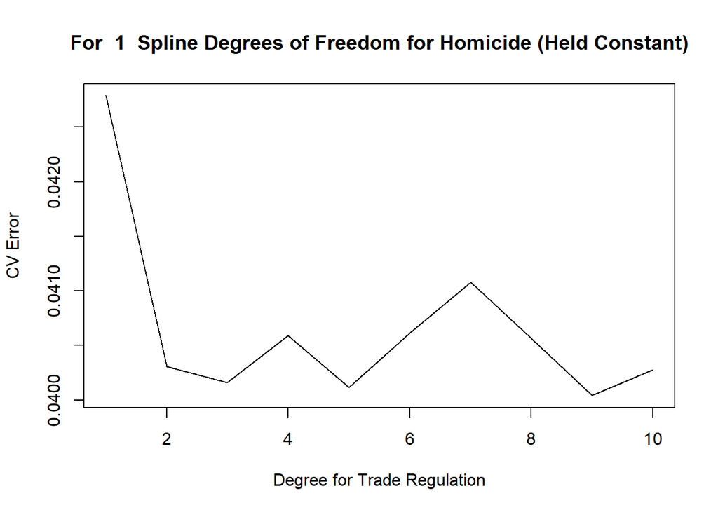

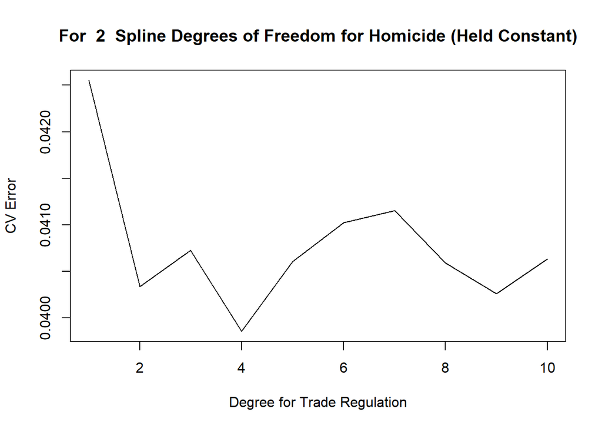

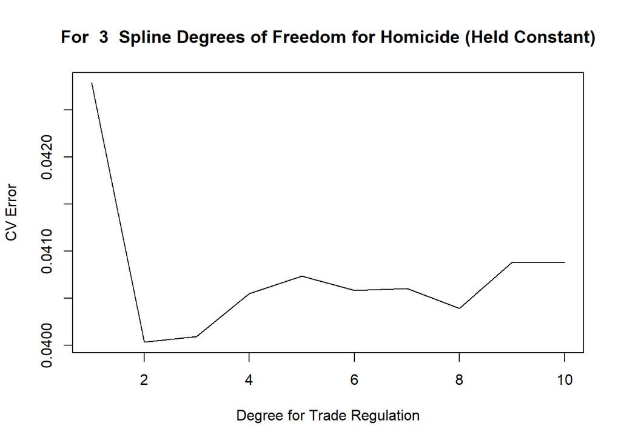

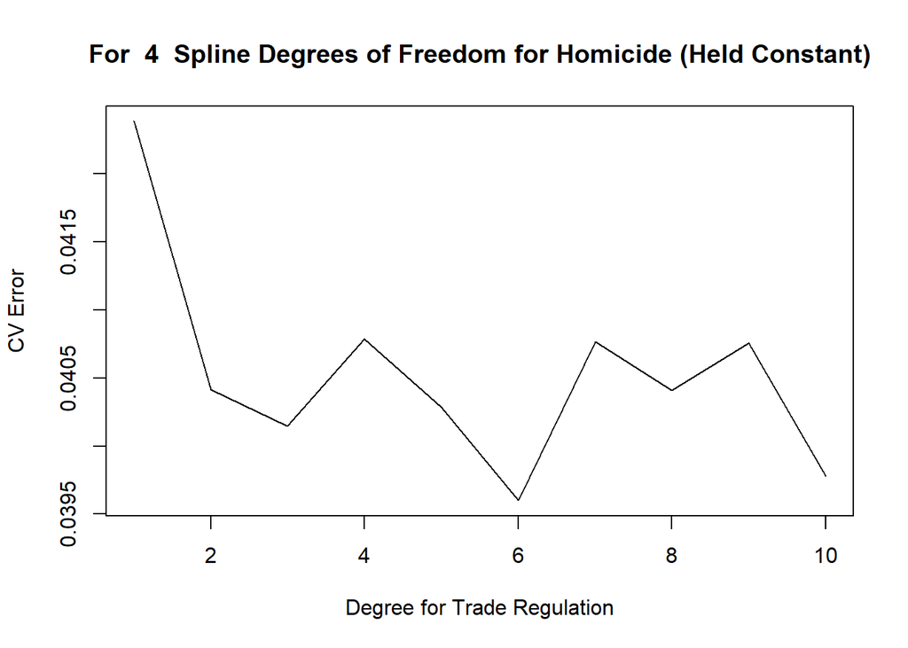

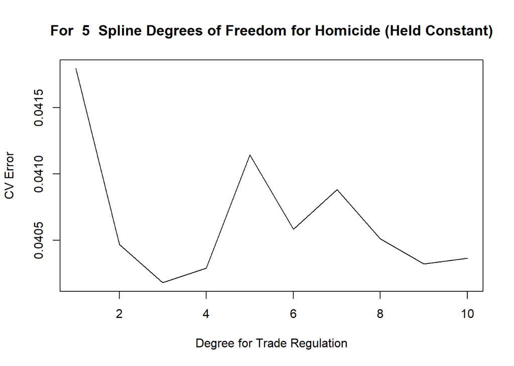

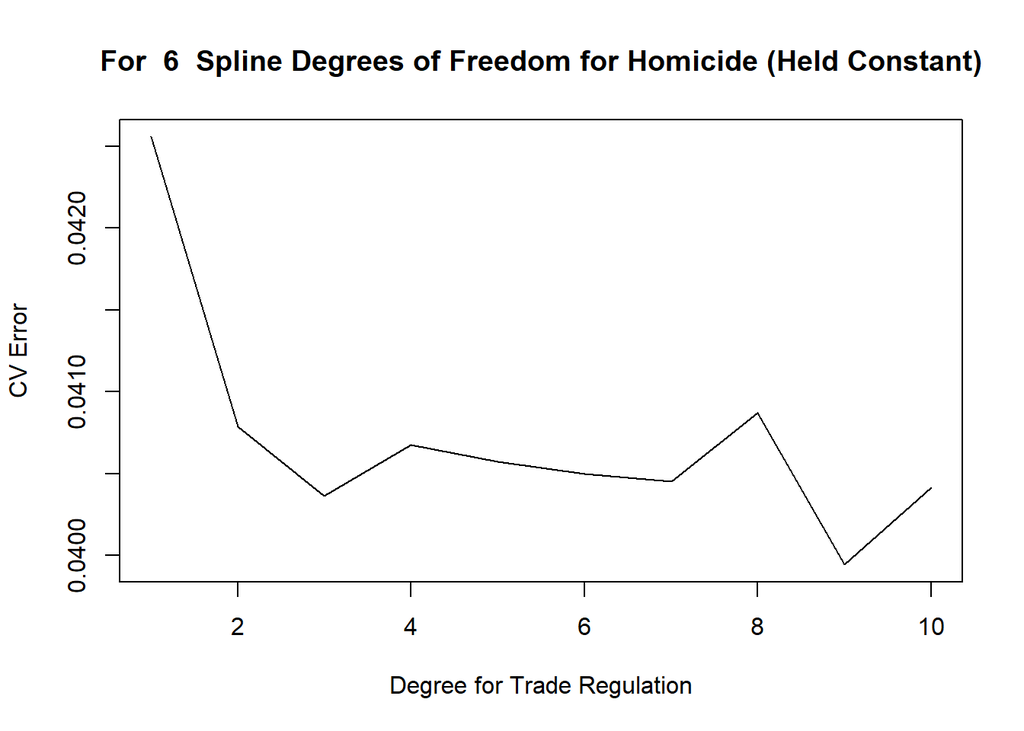

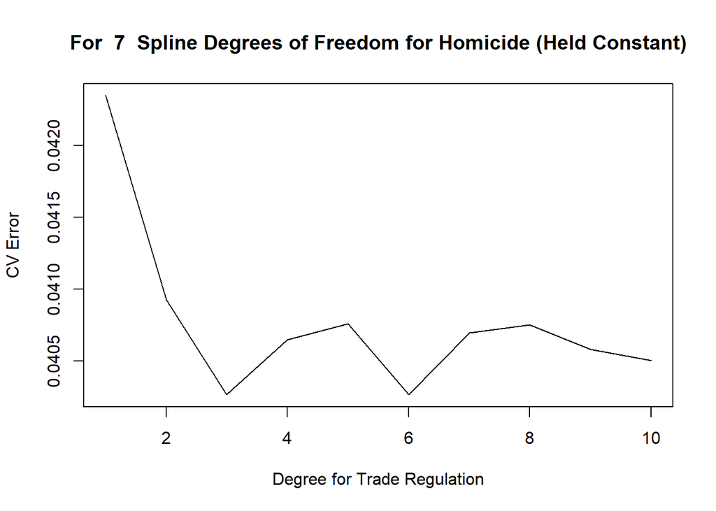

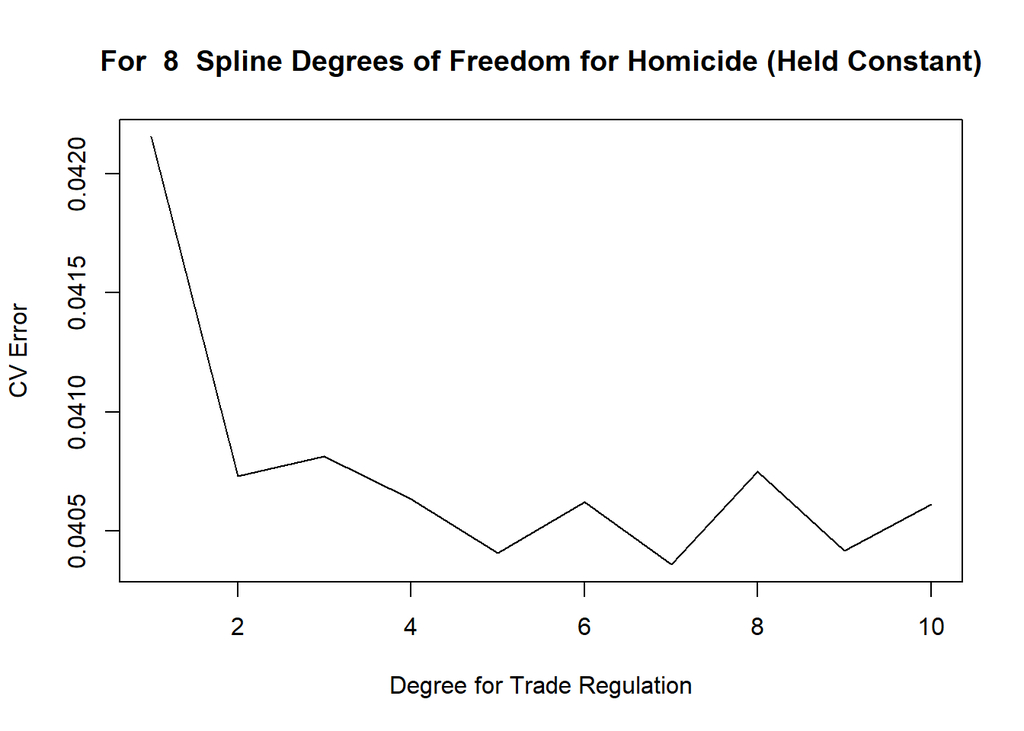

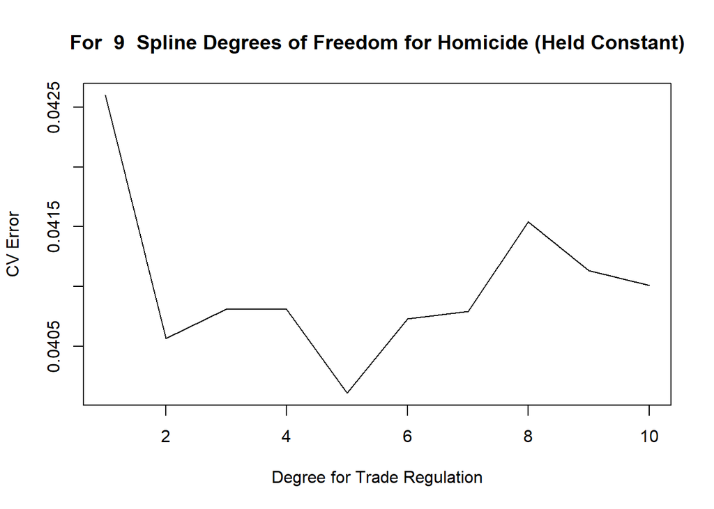

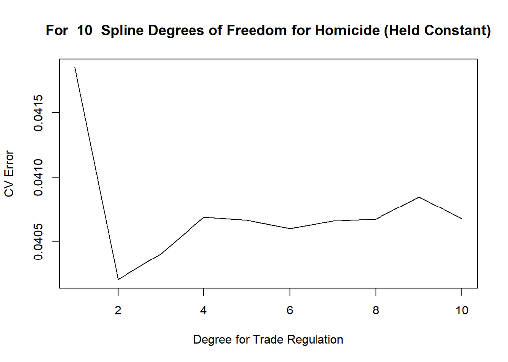

```r
set.seed(111)

CVerrorGam = matrix(data=rep(rep(0, max_spline_term), max_spline_term), nrow=max_spline_term,
                          ncol = max_spline_term)
for (i in 1:max_spline_term) {
  for (j in 1:max_spline_term){
    fit = gam(hf_score ~ ns(pf_ss_homicide, i) + ns(ef_trade_regulatory, j) + . -
                ef_trade_regulatory - pf_ss_homicide, data = hfi_data_combined_train)
    CVerrorGam[i, j] = cv.glm(hfi_data_combined_train, fit, K = 10)$delta[1]
  }
  plot(CVerrorGam[i, 1:max_spline_term],
       main = paste("For ", i, " Spline Degrees of Freedom for Homicide (Held Constant)"),
       xlab = "Degree for Trade Regulation", ylab = "CV Error", type = "l")
}
```

```r
gam_final_best = glm(hf_score ~
                       ns(ef_trade_regulatory, arrayInd(which.min(CVerrorGam), dim(CVerrorGam))[1,2]) +
                       ns(pf_ss_homicide, arrayInd(which.min(CVerrorGam), dim(CVerrorGam))[1,1]) + . - ef_trade_regulatory - pf_ss_homicide,
                     data = hfi_data_combined_train)

yhat = predict(gam_final_best, newdata = hfi_data_combined_test)
gam_test_mse = mean((yhat - hfi_data_combined_test$hf_score)^2)

paste("The degrees of freedom of spline for Homicide:", arrayInd(which.min(CVerrorGam), dim(CVerrorGam))[1,1])
```

```
## [1] "The degrees of freedom of spline for Homicide: 4"
```

```r
paste("The degrees of freedom of spline for Trade Regulation:", arrayInd(which.min(CVerrorGam), dim(CVerrorGam))[1,2])
```

```
## [1] "The degrees of freedom of spline for Trade Regulation: 6"
```

```r
paste("The Cross-Validated MSE for the GAMs tested:", round(min(CVerrorGam)), 6)
```

```
## [1] "The Cross-Validated MSE for the GAMs tested: 0 6"
```

```r
paste("GAM Test MSE:", round(gam_test_mse, 6))
```

```
## [1] "GAM Test MSE: 0.039921"
```

```r
paste("Mean TSS of Test Set:", round(mean_tss_test, 6))
```

```
## [1] "Mean TSS of Test Set: 0.882886"
```

```r
paste("MSE of forward selection MLR model:", round(final_forward_mse, 6))
```

```
## [1] "MSE of forward selection MLR model: 0.042611"
```

Using cross-validation to find the best model that does not overfit with the training data with GAM of variable spline DoF for Homicide and Trade Regulation. The test MSE of the lowest CV MSE for the GAMs tested resulted in a very accurate MSE of 0.039921 compared to the mean TSS of the test set of 0.882886.

We will now perform the GAMs with SMOOTHING splines to try and reduce the variance where the splines split:

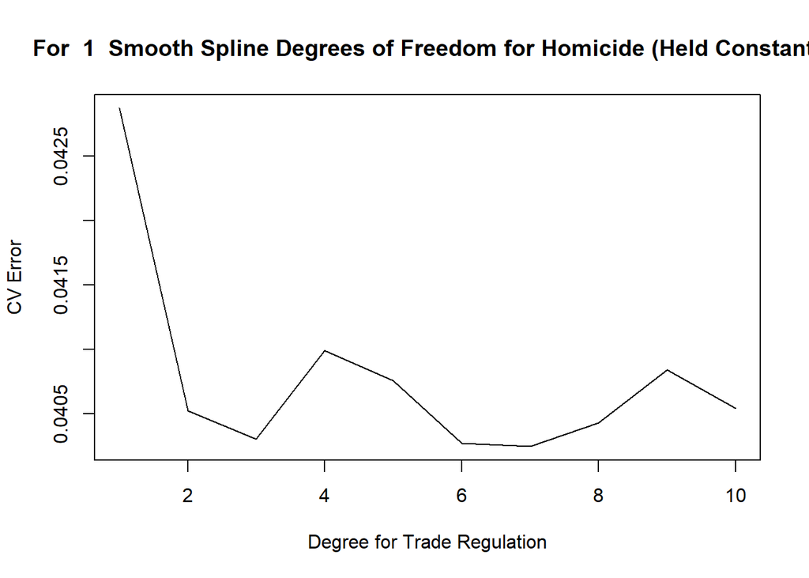

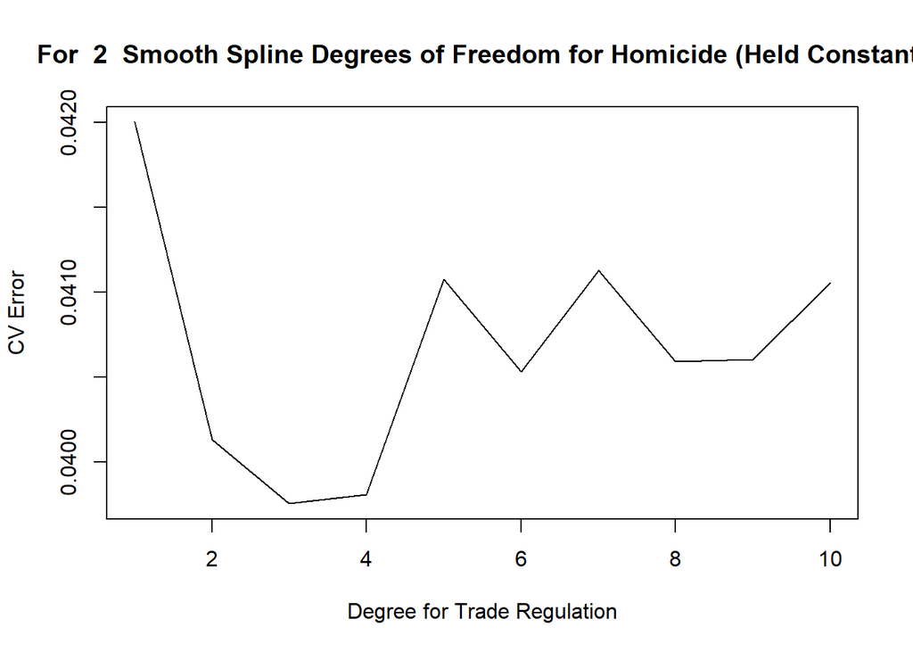

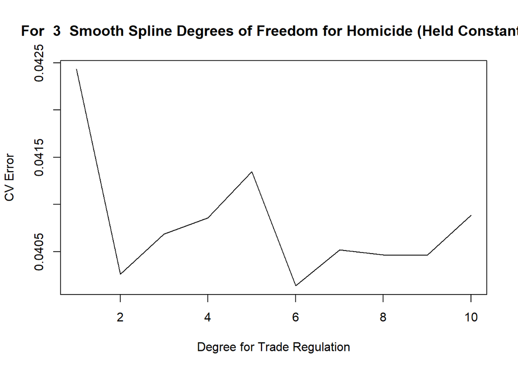

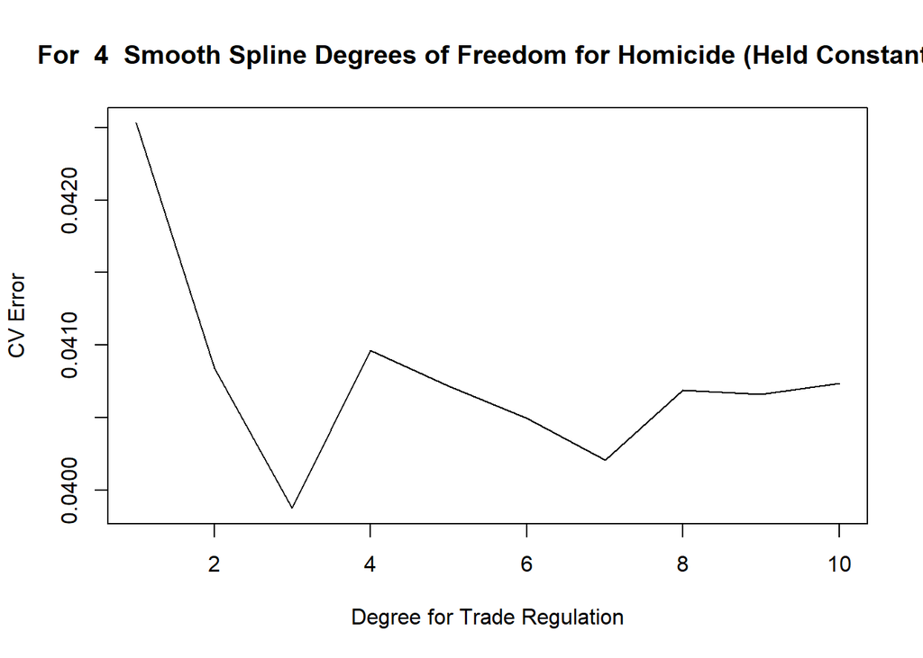

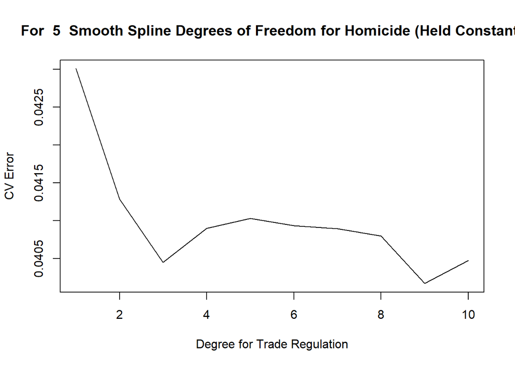

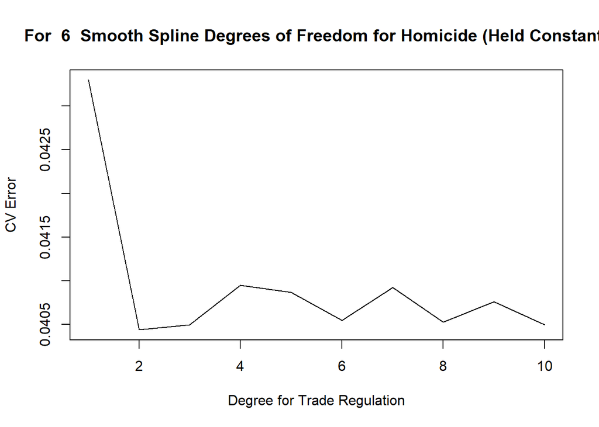

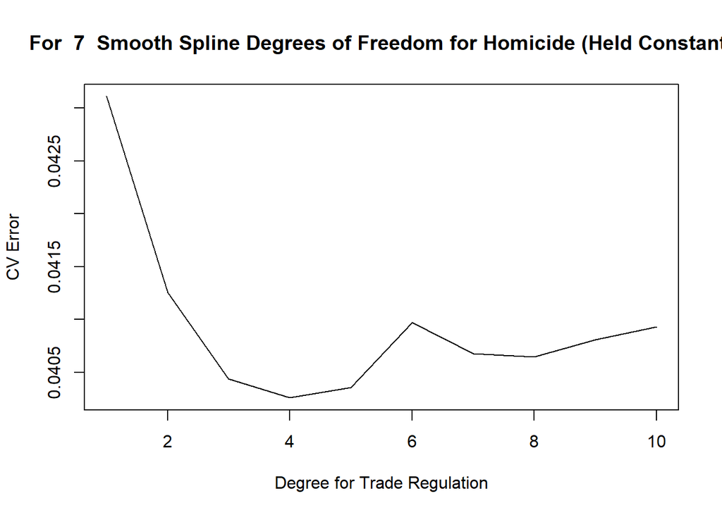

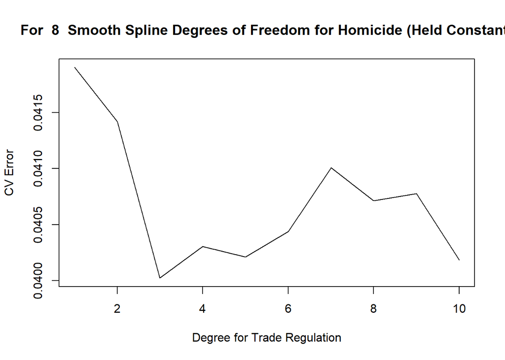

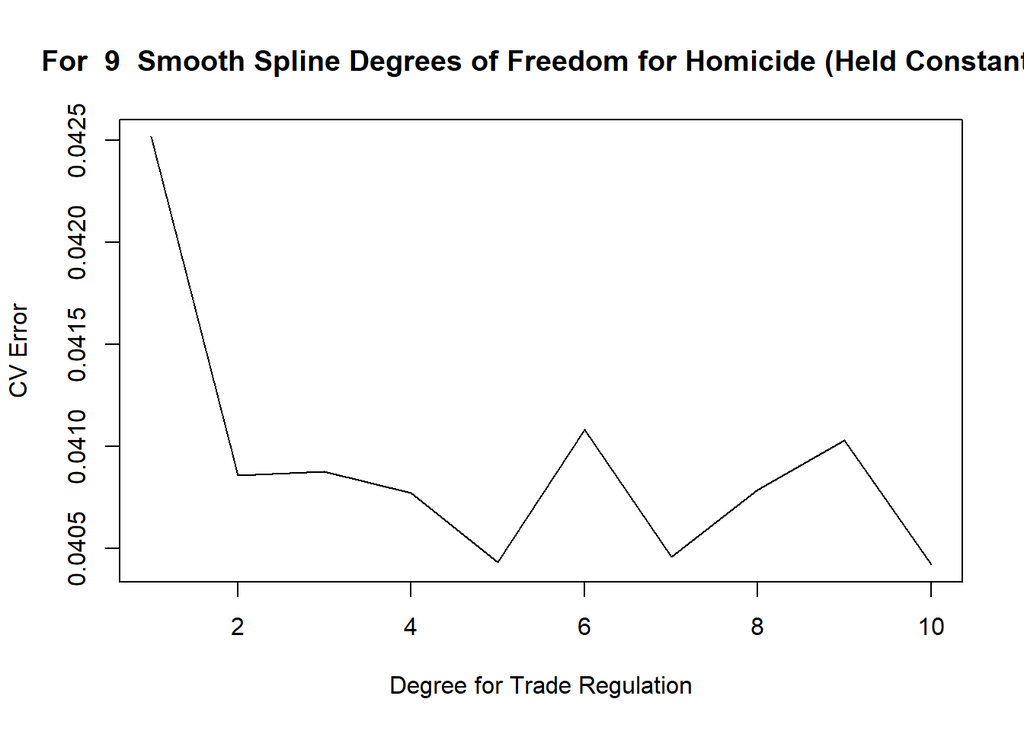

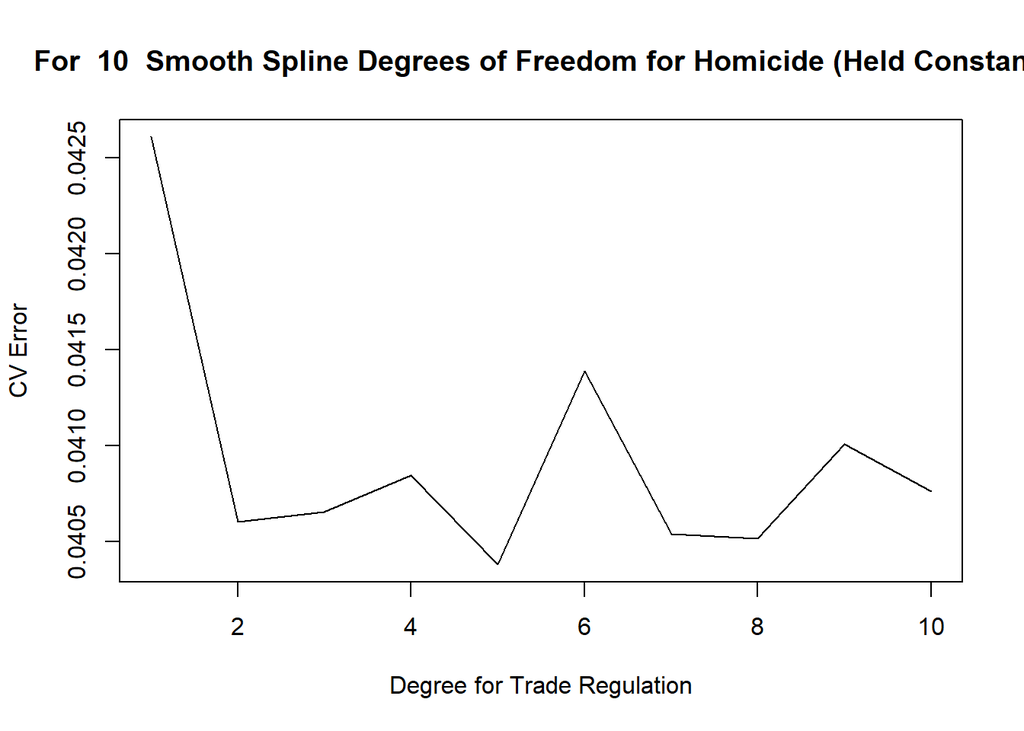

```r
CVerrorGamSmooth = matrix(data=rep(rep(0, max_spline_term), max_spline_term), nrow=max_spline_term,
                          ncol = max_spline_term)
for (i in 1:max_spline_term) {
  for (j in 1:max_spline_term){
    fit = gam(hf_score ~ s(pf_ss_homicide, i) + s(ef_trade_regulatory, j) + . -
                ef_trade_regulatory - pf_ss_homicide, data = hfi_data_combined_train)
    CVerrorGamSmooth[i, j] = cv.glm(hfi_data_combined_train, fit, K = 10)$delta[1]
  }
  plot(CVerrorGamSmooth[i, 1:max_spline_term],
       main = paste("For ", i, " Smooth Spline Degrees of Freedom for Homicide (Held Constant)"),
       xlab = "Degree for Trade Regulation", ylab = "CV Error", type = "l")
}
```

```r
gam_smooth_final_best = glm(hf_score ~
                              s(ef_trade_regulatory, arrayInd(which.min(CVerrorGamSmooth), dim(CVerrorGamSmooth))[1,2]) +
                              s(pf_ss_homicide, arrayInd(which.min(CVerrorGamSmooth), dim(CVerrorGamSmooth))[1,1]) +
                              . - ef_trade_regulatory - pf_ss_homicide, data = hfi_data_combined_train)
yhat = predict(gam_smooth_final_best, newdata = hfi_data_combined_test)
gam_smooth_test_mse = mean((yhat - hfi_data_combined_test$hf_score)^2)

paste("The Results for SMOOTHING Splines")
```

```
## [1] "The Results for SMOOTHING Splines"
```

```r
paste("The degrees of freedom of spline (smoothing) for Homicide:", arrayInd(which.min(CVerrorGamSmooth), dim(CVerrorGamSmooth))[1,1])
```

```
## [1] "The degrees of freedom of spline (smoothing) for Homicide: 2"
```

```r
paste("The degrees of freedom of spline (smoothing) for Trade Regulation:", arrayInd(which.min(CVerrorGamSmooth), dim(CVerrorGamSmooth))[1,2])
```

```
## [1] "The degrees of freedom of spline (smoothing) for Trade Regulation: 3"
```

```r
paste("The Cross-Validated MSE for the GAMs Smoothing Splines tested:", round(min(CVerrorGamSmooth), 6))
```

```
## [1] "The Cross-Validated MSE for the GAMs Smoothing Splines tested: 0.039753"
```

```r
paste("GAM (smoothing splines) Test MSE:", round(gam_smooth_test_mse, 6))
```

```
## [1] "GAM (smoothing splines) Test MSE: 0.042125"
```

```r
paste("Mean TSS of Test Set:", round(mean_tss_test, 6))
```

```
## [1] "Mean TSS of Test Set: 0.882886"
```

```r
paste("MSE of forward selection MLR model:", round(final_forward_mse, 6))
```

```
## [1] "MSE of forward selection MLR model: 0.042611"
```

Smoothing the splines seem to result in a worse model than the non-smoothed splines. This finding indicates we are biasing the model in a negative way by forcing the smoothing of splines.

Overall, the resulting GAMs are very accurate and minimize the MSE either equal or marginally better than the best-subset of MLR model. However, the added complexity and variance of the model seems unnecessary for less than a 1% improvement of the test MSE. We prefer the polynomial regression to the GAMs because the splines and GAMs tend to have large degrees of freedom to capture more variance, but it fails to deliver better results (granted the results of plain MLR are already very good).

In conclusion, we prefer the best-subset or forward selection models as they tend to be very close in accuracy as the polynomial regression, splines, and GAMs while being simpler.

## 4.4 KNN Regression

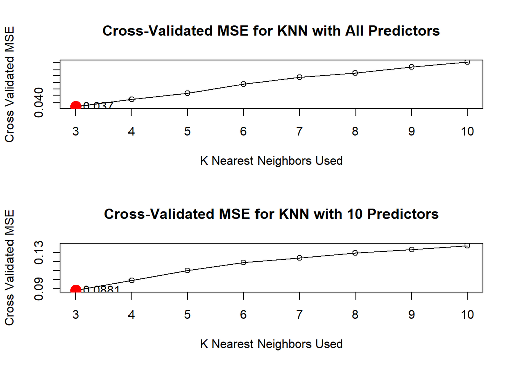

```r
#########################    KNN REGRESSION   #############################
# simply used to get same results regardless of run. Methods should be robust to the seed changing, though
set.seed(111)

# Lowest and Highest value of k allowed
k_folds = 10
top_correlated = 11 # really is 10 as hf_score is included; so 11 - 1 = 10 most correlated predictors
lowest_k = 3
highest_k = 10 # could do higher, but the lower the 'K' is, the better the results

# 2 by 1 graphs
par(mfrow=c(2,1))

do_knn = function(title_string, is_top_correlated){
  # the cross-validated MSE of all K
  knn_regression_mse = rep(-1,highest_k - lowest_k + 1)
  for(k in lowest_k:highest_k){
    if(is_top_correlated){
      knn_reg = knn.reg(train = (hfi_data_combined_train %>%
                                   select(c(names(abs_sorted_hf_score_correlations %>% head(top_correlated))), -hf_score)),
                      y = hfi_data_combined_train$hf_score, k = k)
    }else{
      knn_reg = knn.reg(train = (hfi_data_combined_train %>% select(-hf_score)),
                        y = hfi_data_combined_train$hf_score, k = k)
    }

    knn_regression_mse[k - lowest_k + 1] = mean((knn_reg$pred - hfi_data_combined_train$hf_score)^2)
  }

  plot(main = title_string, x=lowest_k:highest_k, y = knn_regression_mse,
       xlab = "K Nearest Neighbors Used", ylab = "Cross Validated MSE") +
    lines(x=lowest_k:highest_k, y = knn_regression_mse) +
    points(x = (which.min(knn_regression_mse) + lowest_k - 1),
           y = min(knn_regression_mse), col ="red", cex=2, pch =19) +
    text(x = (which.min(knn_regression_mse) + lowest_k - 1), y = min(knn_regression_mse),
         labels = paste(round(min(knn_regression_mse), 4)), pos = 4)

  knn_regression_mse
}

# do KNN regression with 1ll 39 predictors
knn_regression_mse_default = do_knn(title_string = "Cross-Validated MSE for KNN with All Predictors",
                                    is_top_correlated = FALSE)



# Try with only limited variables
# this will select the top_correlated highest correlated vars with hf_score
# then attempt the KNN regression on this smaller dataset
knn_regression_mse_diff = do_knn(title_string = paste("Cross-Validated MSE for KNN with", top_correlated - 1, "Predictors"),
                                 is_top_correlated = TRUE)
```

```r
# test the 3-k models
knn_default_best = knn.reg(train = (hfi_data_combined_train %>% select(-hf_score)),
                           test = (hfi_data_combined_test %>% select(-hf_score)),
                           y = hfi_data_combined_train$hf_score,
                           k = (lowest_k - 1 + which.min(knn_regression_mse_default)))
knn_default_test_mse = mean((knn_default_best$pred - hfi_data_combined_test$hf_score)^2)


knn_limit_pred_best = knn.reg(train = (hfi_data_combined_train %>%
                                      select(c(names(abs_sorted_hf_score_correlations %>% head(top_correlated))), -hf_score)),
                           test = (hfi_data_combined_test %>%
                                     select(c(names(abs_sorted_hf_score_correlations %>% head(top_correlated))), -hf_score)),
                           y = hfi_data_combined_train$hf_score,
                           k = (lowest_k - 1 + which.min(knn_regression_mse_diff)))
knn_limit_pred_best_mse = mean((knn_limit_pred_best$pred - hfi_data_combined_test$hf_score)^2)


paste("The Predictors Used in the", top_correlated - 1, "Predictor Model:",
      paste(c(names(abs_sorted_hf_score_correlations %>% head(top_correlated))), collapse = ", "))
```

```
## [1] "The Predictors Used in the 10 Predictor Model: hf_score, pf_expression_control, pf_expression_influence, ef_legal_military, ef_trade_regulatory, ef_trade_regulatory_compliance, ef_legal_gender, ef_trade_tariffs_mean, pf_movement_domestic, ef_money_sd, ef_regulation_credit"
```

```r
paste("The Mean TSS of the Test Set:", round(mean_tss_test, 6))
```

```
## [1] "The Mean TSS of the Test Set: 0.882886"
```

```r
paste("The Test MSE of Forward Selection MLR:", round(final_forward_mse, 6))
```

```
## [1] "The Test MSE of Forward Selection MLR: 0.042611"
```

```r
paste("The Test MSE of ALL 39 Predictor Model:", round(knn_default_test_mse, 6))
```

```
## [1] "The Test MSE of ALL 39 Predictor Model: 0.031429"
```

```r
paste("The Test MSE of", top_correlated, "Predictor Model:", round(knn_limit_pred_best_mse, 6))
```

```
## [1] "The Test MSE of 11 Predictor Model: 0.108217"
```

```r
# 1 by 1 graphs
par(mfrow=c(1,1))
```

There are 2 different KNN regressions. Both regressions are tested on the training set using cross validation (Leave one out cross-validation). We take the best cross-validated K, and create those models. The first KNN model uses all 39 predictors. The second KNN model uses the top 10 correlated predictors only using KNN regression. For both models, the value for ‘K’ is 3. It seems that the lower the K, the more accurate the model becomes.

- The 39 Predictor model returns an impressive Test MSE of 0.031429. The Test MSE is superior to the MLR Test MSE from forward selection (0.042611).
- The top 10 KNN model returns a less impressive Test MSE of 0.108217 compared to the forward selection model (using ~30 predictors) of 0.042611. Even though the MSE is not as good as the full 39 predictor model nor the MLR model, it does surprisingly well with fewer predictors.

Overall, the KNN regression results in the lowest test MSE seen so far. The model seems to be very accurate, especially with all predictors being used to train the model. However, KNN is unsupervised, and therefore we have very little ability to judge which predictors are most important. Additionally, the test MSE is lower than the MLR, but it only explains ~1-2% more variance within the data. This small difference in model variance explained, is not enough to merit this model over the MLR methods performed beforehand. Thus, we will not focus on KNN as it fails to deliver meaningful insights regarding predictor significance or importance.

An important note is that K=3 is the most variant model we can create. Meaning the data does not seem to overfit with additional variance within a model. This finding indicates the data is heavily correlated and linked together, which it is.

## 4.5 Conclusions on Non-Linear Methods

Overall, the non-linear methods due capture more variance than the MLR models, however, the gains in prediction ability (lower MSE) come at the cost of inferencing ability. This inferencing ability for MLR allows us to determine with ease the most significant predictors using T-tests and F-Tests. The polynomial terms for Homicide and Trade Regulation is something to keep in mind for the final part of our analysis. The polynomial terms in a smaller model may help increase accuracy. The splines, GAMs, and smoothed spline GAMs offered some better models (GAMs with non-smoothed splines), but failed to significantly improve accuracy compared to the forward regression model. In conclusion, we decided to sill prefer the best-subset model over these non-linear models as an improvement of accuracy equal to **less** than 1% is not worth the less inferencing ability and added complexity over the basic MLR.

# 5. Tree-Based Methods

## 5.1 Standard Regression Tree

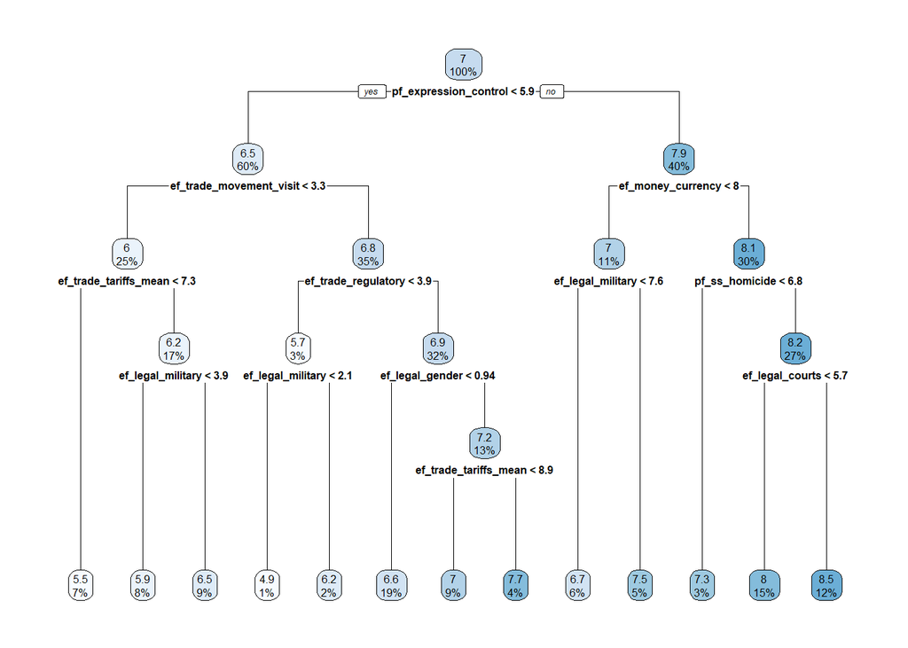

```r
# simply used to get same results regardless of run. Methods should be robust to the seed changing, though
set.seed(111)

par(mfrow=c(1,1))

# Standard Regression Tree
tree_regression = rpart(hf_score ~ ., data=hfi_data_combined_train)
rpart.plot(tree_regression)
```

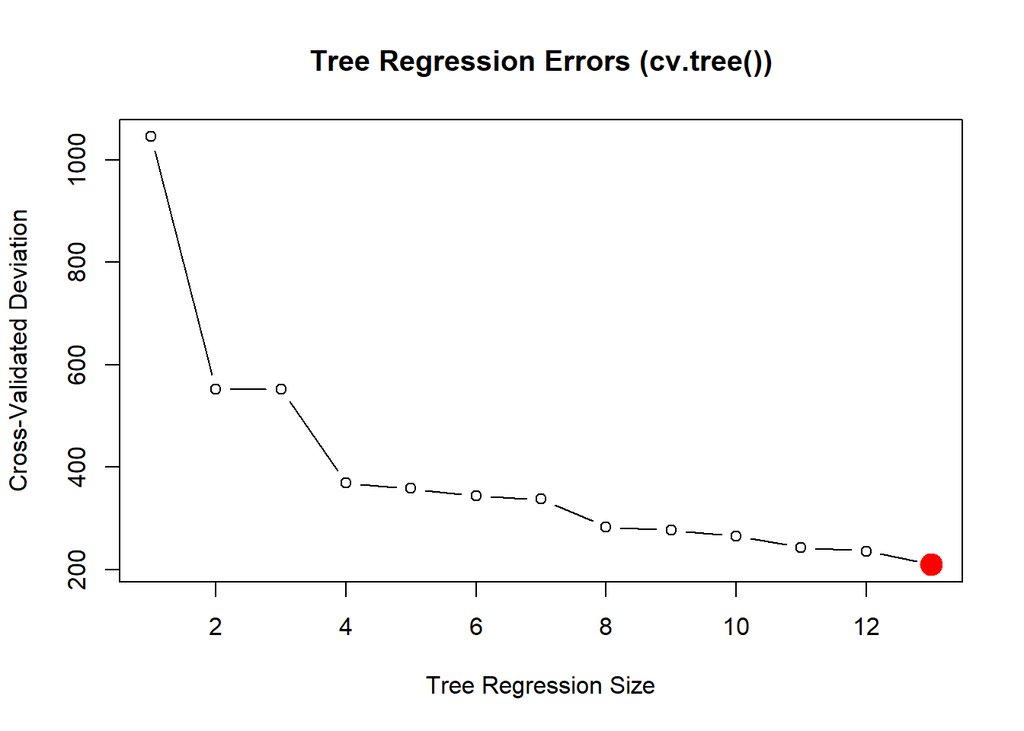

```
## integer(0)
```

```r
# the tree is the same as above, but rpart has nice plotting
cv_tree_base = tree(hf_score ~ ., data=hfi_data_combined_train)
cv_tree_regression = cv.tree(cv_tree_base, K = k_folds)
plot(cv_tree_regression$size, cv_tree_regression$dev, type="b",
     main = "Tree Regression Errors (cv.tree())",
     ylab = "Cross-Validated Deviation", xlab = "Tree Regression Size") +
  points(cv_tree_regression$size[which.min(cv_tree_regression$dev)],
         min(cv_tree_regression$dev),
         col="red", cex = 2, pch = 19)
```

No pruning is needed as the cross-validated tree shows it performs best with the most complex model.

### A further look into the tree:

```r
## No pruning is needed. Most complex model is best model.
summary(cv_tree_base)
```

```
##
## Regression tree:
## tree(formula = hf_score ~ ., data = hfi_data_combined_train)
## Variables actually used in tree construction:
## [1] "pf_expression_control"   "ef_trade_movement_visit"
## [3] "ef_trade_tariffs_mean"   "ef_legal_military"
## [5] "ef_trade_regulatory"     "ef_legal_gender"
## [7] "ef_money_currency"       "pf_ss_homicide"
## [9] "ef_legal_courts"
## Number of terminal nodes:  13
## Residual mean deviance:  0.1466 = 151.1 / 1031
## Distribution of residuals:
##      Min.   1st Qu.    Median      Mean   3rd Qu.      Max.
## -1.557000 -0.211900  0.003695  0.000000  0.215800  1.482000
```

```r
# Test on the test set
tree_predictions = predict(cv_tree_base, newdata = hfi_data_combined_test)
pruned_tree_test_mse = mean((tree_predictions - hfi_data_combined_test$hf_score) ^ 2)
```

The “Residual Mean Deviance” is the MSE and it does significantly worse than the linear models and dimension reduction models (0.14 versus < 0.05; smaller the better). The test MSE is 0.168124 which again makes the tree look like a much worse model than the linear models and non-linear models above.

## 5.2 Bagging and Random Forests

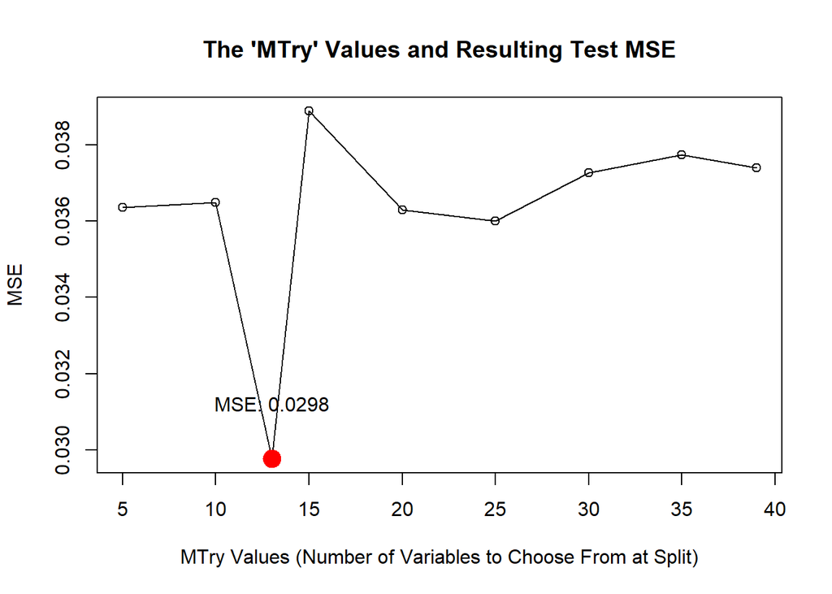

```
## integer(0)
```

```r
# RANDOM FOREST AND BAGGING
set.seed(111)
default_ntrees = 500


# Store the TEST MSE for all MTrys we are testing
random_forests = data.frame(MTry = numeric(9), Test_MSE = numeric(9))
forest_i = 1
for (current_mtry in seq(from = 5, to = 35, by = 5)){
  random_forest = randomForest(hf_score ~ ., data = hfi_data_combined_train,
                       ntree = default_ntrees, mtry = ncol(hfi_data_combined_train) - 1)
  yhat = predict(random_forest, newdata = hfi_data_combined_test)
  random_forests$MTry[forest_i] = current_mtry
  random_forests$Test_MSE[forest_i] = mean((yhat - hfi_data_combined_test$hf_score)^2)
  forest_i = forest_i + 1
}


# BAGGING (MTY == 39 or all possible predictors)
random_forest = randomForest(hf_score ~ ., data = hfi_data_combined_train,
                       ntree = default_ntrees, mtry = ncol(hfi_data_combined_train) - 1)
# bagging; Subtract 1 for the hf_score response in the dataframe
random_forests$MTry[forest_i] = ncol(hfi_data_combined_train) - 1
yhat = predict(random_forest, newdata = hfi_data_combined_test)
random_forests$Test_MSE[forest_i] = mean((yhat - hfi_data_combined_test$hf_score)^2)
forest_i = forest_i + 1


# p/3; this is the recommended value of 'MTry'
recommended_forest = randomForest(hf_score ~ ., data = hfi_data_combined_train,
                       ntree = default_ntrees, mtry = round((ncol(hfi_data_combined_train) - 1)/ 3),
                       importance = TRUE)

random_forests$MTry[forest_i] = round((ncol(hfi_data_combined_train) - 1)/ 3)
yhat = predict(recommended_forest, newdata = hfi_data_combined_test)
random_forests$Test_MSE[forest_i] = mean((yhat - hfi_data_combined_test$hf_score)^2)
forest_i = forest_i + 1


random_forests = random_forests %>% arrange(MTry)

plot(x = random_forests$MTry, y = random_forests$Test_MSE, type = "line",
     main = "The 'MTry' Values and Resulting Test MSE", ylab = 'MSE',
     xlab = "MTry Values (Number of Variables to Choose From at Split)") +
  points(x = random_forests$MTry, y = random_forests$Test_MSE) +
  points(x = random_forests$MTry[which.min(random_forests$Test_MSE)],
         y = min(random_forests$Test_MSE), col="red", cex = 2, pch = 19) +
  text(x = random_forests$MTry[which.min(random_forests$Test_MSE)],
       y = min(random_forests$Test_MSE),
       labels = paste("MSE:", round(min(random_forests$Test_MSE),4) ),
       pos = 3, offset = 2)
```

```r
# Importance from Recommended MTry of p/3

paste("The Mean TSS for the Test Set:", round(mean_tss_test, 6))
```

```
## [1] "The Mean TSS for the Test Set: 0.882886"
```

```r
paste("The Test MSE for the Forward Selection MLR Model:", round(final_forward_mse, 6))
```

```
## [1] "The Test MSE for the Forward Selection MLR Model: 0.042611"
```

```r
paste("The following Test MSE for Random Forest of Varying MTrys:")
```

```
## [1] "The following Test MSE for Random Forest of Varying MTrys:"
```

```r
random_forests
```

| MTry | Test_MSE |
| --- | --- |
| 5 | 0.03636563 |
| 10 | 0.03648366 |
| 13 | 0.02976794 |
| 15 | 0.03888583 |
| 20 | 0.03629059 |
| 25 | 0.03600169 |
| 30 | 0.03726412 |
| 35 | 0.03773972 |
| 39 | 0.03739804 |

```r
a = as.data.frame(recommended_forest$importance)
colnames(a)[1] = "IncMSE"
a %>% arrange(desc(IncMSE)) %>% head(20)
```

|  | IncMSE | IncNodePurity |
| --- | --- | --- |
| pf_expression_control | 0.16925608 | 192.417524 |
| pf_expression_influence | 0.13618930 | 153.811308 |
| ef_trade_tariffs_mean | 0.11450204 | 105.314494 |
| ef_legal_gender | 0.10613598 | 61.401821 |
| ef_trade_regulatory | 0.07248463 | 77.953543 |
| ef_trade_regulatory_compliance | 0.06975010 | 75.675454 |
| ef_legal_military | 0.06780429 | 62.870452 |
| ef_trade_movement_visit | 0.05412679 | 32.715250 |
| pf_ss_homicide | 0.04440094 | 23.590177 |
| ef_regulation_credit | 0.03503951 | 28.255045 |

[output cut: 10 more lines]

The bagged model results in an MSE of 0.037398. The best model with the lowest MSE was 0.029768.

Like KNN, this model results in a very low test MSE, meaning that it is very good for prediction. But because the random forest is complex, there is limited inferencing available. However, random forest does have a proxy for significant predictors within the model by measuring importance. The importance is measured by how much of the model variance is explained by a singular predictor. This measurement is calculated by removing the predictor from the model and seeing how much worse the resulting MSE would be. This importance is not nearly as mathematical and robust as the T-tests or F-tests for MLR, unfortunately.

The most important predictors are:

- pf_expression_control (the control over citizen personal expression like speech)
- pf_expression_influence (the amount of government influence on expression like ownership of media)
- ef_legal_gender (how equal the economic system is for men versus women)
- ef_trade_tariffs_mean (how large the average tariffs are)
- ef_trade_regulatory (how much economic and trade regulation there is within country)

We will keep these predictors in mind for our final analysis.

## 5.3 Boosting

```r
# BOOSTING
set.seed(111)

exponents = seq(-3, 0, by = 0.1)
lambda = 0.02  # from preliminary tests, this seems consistently good; reduces time significantly
default_ntrees = 3000
max_inter_depth = 3  # this is more reasonable, typically, one does not need many leaf nodes per tree
max_inter_depth = 5  # this is excessive. Will take a while. Only used to get overfitting in model.

boosting_test_mse = rep(NA, 4)

paste("The Mean TSS for the Test Set:", round(mean_tss_test, 6))
```

```
## [1] "The Mean TSS for the Test Set: 0.882886"
```

```r
paste("The MSE for the Forward Selection MLR Model:", round(final_forward_mse, 6))
```

```
## [1] "The MSE for the Forward Selection MLR Model: 0.042611"
```

```r
for( inter_depth in 1:max_inter_depth){
  boosting_gbm = gbm(hf_score ~ ., data = hfi_data_combined_train,
                     distribution="gaussian", interaction.depth = inter_depth,
                     n.trees=default_ntrees, shrinkage = lambda,
                     cv.folds = 10)

  yhat = predict(boosting_gbm, newdata = hfi_data_combined_test, n.trees = default_ntrees)
  boosting_test_mse[inter_depth] = mean((yhat - hfi_data_combined_test$hf_score)^2)

  print(paste("At Maximum Inter-Depth: ", inter_depth))
  print(paste("10-Fold Cross-Validation Error Estimate is",
              round(boosting_gbm$cv.error[default_ntrees], 6)))
  print(paste("Test MSE:", round(boosting_test_mse[inter_depth], 6)))
  print(paste("Mean TSS of Test Set:", round(mean_tss_test, 6)))
}
```

```
## [1] "At Maximum Inter-Depth:  1"
## [1] "10-Fold Cross-Validation Error Estimate is 0.037806"
## [1] "Test MSE: 0.038161"
## [1] "Mean TSS of Test Set: 0.882886"
## [1] "At Maximum Inter-Depth:  2"
## [1] "10-Fold Cross-Validation Error Estimate is 0.026671"
## [1] "Test MSE: 0.024575"
## [1] "Mean TSS of Test Set: 0.882886"
## [1] "At Maximum Inter-Depth:  3"
## [1] "10-Fold Cross-Validation Error Estimate is 0.023438"
## [1] "Test MSE: 0.021805"
## [1] "Mean TSS of Test Set: 0.882886"
## [1] "At Maximum Inter-Depth:  4"
## [1] "10-Fold Cross-Validation Error Estimate is 0.020807"
## [1] "Test MSE: 0.019383"
## [1] "Mean TSS of Test Set: 0.882886"
## [1] "At Maximum Inter-Depth:  5"
## [1] "10-Fold Cross-Validation Error Estimate is 0.020529"
## [1] "Test MSE: 0.0198"
## [1] "Mean TSS of Test Set: 0.882886"
```

```r
boosting_depth_4 = gbm(hf_score ~ ., data = hfi_data_combined_train,
                       distribution="gaussian", interaction.depth = 4,
                       n.trees=default_ntrees, shrinkage = lambda,
                       cv.folds = 10)

boosting_depth_1 = gbm(hf_score ~ ., data = hfi_data_combined_train,
                       distribution="gaussian", interaction.depth = 1,
                       n.trees=default_ntrees, shrinkage = lambda,
                       cv.folds = 10)

par(mfrow=c(1,1))
```

Here we perform boosting on the training set with `default_ntrees` trees with an initial round for each model selection. Since boosting takes a significant amount of time to run, we did some testing that seemed to indicate 0.02 is a good lambda value to use. The initial lambda value we used was 0.01, so very close to the standard. The shrinkage (lambda) parameter dictates how ‘fast’ the boosting model ‘learns.’ Lower the shrinkage, the slower the model learns; larger, the faster. Obviously faster learning sounds strictly better, but that is not the case. If the learning is too fast, then the model tends to overfit. If the model learns too slow, the model does not have enough iterations of tree creation to capture the variance.

Overall, boosting does better than the MLR forward selection model’s Test MSE of 0.042611 compared to boosting models’ Test MSEs of around ~0.02. Still, linear models have more use to us because of T-tests and F-tests, but these tree models (random forests and boosting) do deliver some impressive results and some insights. The insights on predictor importance are below:

## 5.4 Predictor Importance from Random Forests and Boosting

We ignore the simple decision tree regression model as the MSE was disappointing. All other models above outperformed the tree model.

We choose the recommended MTry size of 13 predictors (1/3 number of predictors) as the results were the best (or very marginally off of the best). ### The following output is the **most Important** predictors within the random forest model with MTry = 13 (recommended value): S

```r
top_n_important_preds = 20

# show the summary() of the RF (Mtry = 13)
rf_imp = as.data.frame(recommended_forest$importance)
rf_imp %>% dplyr::arrange(desc(rf_imp$`%IncMSE`)) %>% head(top_n_important_preds)
```

|  | %IncMSE | IncNodePurity |
| --- | --- | --- |
| pf_expression_control | 0.16925608 | 192.417524 |
| pf_expression_influence | 0.13618930 | 153.811308 |
| ef_trade_tariffs_mean | 0.11450204 | 105.314494 |
| ef_legal_gender | 0.10613598 | 61.401821 |
| ef_trade_regulatory | 0.07248463 | 77.953543 |
| ef_trade_regulatory_compliance | 0.06975010 | 75.675454 |
| ef_legal_military | 0.06780429 | 62.870452 |
| ef_trade_movement_visit | 0.05412679 | 32.715250 |
| pf_ss_homicide | 0.04440094 | 23.590177 |
| ef_regulation_credit | 0.03503951 | 28.255045 |

[output cut: 10 more lines]

### The following output is the **most Influential** (or Important) predictors within the boosting model with inter-depth = 4:

```r
# the plots for boosting summary do not work well with our labels
summary(boosting_depth_4, plotit=FALSE) %>% select(rel.inf) %>% head(top_n_important_preds)
```

|  | rel.inf |
| --- | --- |
| pf_expression_control | 20.3484115 |
| ef_trade_tariffs_mean | 12.2486287 |
| ef_trade_regulatory_compliance | 9.4910075 |
| pf_expression_influence | 7.4997698 |
| ef_trade_regulatory | 7.4691922 |
| ef_legal_gender | 7.1773834 |
| ef_legal_military | 4.1598740 |
| ef_regulation_credit | 4.0093249 |
| ef_trade_movement_visit | 3.1976280 |
| ef_money_currency | 2.8441064 |

[output cut: 10 more lines]

We additionally use the default boosting model of inter-depth 1 (simple stub trees with only 1 leaf node created). This hyper-parameter for inter-depth is commonly used. We also got very promising results from this basic boosting model.

### The following output is the **most Influential** (or Important) predictors within the boosting model with inter-depth = 1:

```r
summary(boosting_depth_1, plotit=FALSE) %>% select(rel.inf) %>% head(top_n_important_preds)
```

|  | rel.inf |
| --- | --- |
| pf_expression_control | 16.6045671 |
| ef_trade_tariffs_mean | 11.6735087 |
| ef_trade_regulatory_compliance | 10.2401482 |
| ef_legal_gender | 9.4644370 |
| pf_expression_influence | 8.6794647 |
| ef_trade_regulatory | 7.4036403 |
| ef_legal_military | 4.8357756 |
| ef_money_sd | 4.7248777 |
| ef_trade_movement_capital | 3.2960017 |
| ef_regulation_credit | 2.6468564 |

[output cut: 10 more lines]

There seem to be some overlap in predictor relevance (significance or importance; all mean roughly the same) between the 3 models above. We will further analyze these results combined with the predictors found to be significant in other models (namely the MLR model found using forward selection and best-subset selection).

# 6. Conclusions from Analysis for Simplified Model

This section will look at the overall results and findings from the completed methods and analyses above. This section will primarily target task 2 from our goals for the project (identify the most significant or relevant or influential predictors regarding human freedom). Then, we will attempt to simplify our models with the knowledge that certain predictors seem to be important, while other predictors less so.

## 6.1 Initial Conclusions

Overall, many methods we used seemed to yield very accurate results (consistently more than 90% of the variance was explained). These findings help confirm that the human freedom score we were predicting is made up of these more specific predictors/variables. Potentially, the human freedom score is some weighted average of all 39 (maybe more predictors that we removed at the beginning during data tidying). The CATO Institute has a 400+ page manual and description of their Human Freedom Index. It details how certain variables (predictors within our model) are calculated, but we could not derive their method of calculating the final human freedom score (hf_score).

Our preliminary conclusions are:

1. The Human Freedom Index has many predictors, many of which may be unnecessary. We tested various models with only 10 or 15 predictors, and yielded very accurate models (roughly equivalent to 85% R-Squared). Thus, we will later craft a simplified model that uses 10 - 20 predictors to minimize the MSE (maximize variance explained) and allow an easier model to comprehend as a human.
2. Certain predictors tend to be used in all models. Such as: pf_ss_homicide, pf_expression_control, ef_trade_regulatory / ef_trade_regulatory_compliance, pf_expression_influence, ef_legal_gender. Many of these predictors make sense for the high correlation with human freedom. If people are likely to be murdered, the human freedom of that country is probably lower. On the other hand, if media and expression (like art, discussions, public meetings) are not controlled by the government (like no censorship), then human freedom tends to be greater.

## 6.2 The Predictor Analysis

We will highlight the various models that performed very well in an effort to highlight some of the most important / influential / significant predictors for human freedom. Then, we can use these findings to create as smaller, simplified model using a subset of the 39 total predictors.

### Boosting Models’ Findings Regarding Predictors:

The best model we found was the boosting model of inter-depth = 4 (inter-depth of 1 was also very accurate) . The boosting model performed with an MSE around 0.02 (which equates to an R-Squared = ~97%). This accuracy is impressive and the predictors it viewed most influential on the model were pf_expression_control, ef_trade_tariffs_mean, ef_trade_regulatory_compliance, pf_expression_influence, ef_trade_regulatory, ef_legal_gender, ef_legal_military, ef_regulation_credit, ef_trade_movement_visit, ef_money_currency. We used the output from the above models (5.4) regarding rel.inf (relative influence on human freedom).

### Random Forest Models’ Findings Regarding Predictors:

Another very accurate model was the Random Forest model with Mtry of 13. The predictors that the model gave the greatest importance level were: pf_expression_control, pf_expression_influence, ef_legal_gender, ef_trade_tariffs_mean, ef_trade_regulatory, ef_trade_regulatory_compliance, ef_legal_military, ef_trade_movement_visit, pf_ss_homicide, ef_regulation_credit. We used the output from above models (5.4) regarding the importance metric for estimating the importance of a predictor on human freedom.

### Multiple Linear Regression Models’ Findings Regarding Predictors:

However, the basic Multiple Linear Regression model from forward selection and best-subset selection performed near these other 2 models with an MSE of roughly 0.042 for an R-Squared of roughly 95%. Very accurate model and very good for predictor inference. The predictors the MLR model found to be most significant were: pf_ss_homicide, ef_legal_gender, ef_legal_courts, ef_legal_military, ef_money_currency, ef_government_consumption, ef_legal_enforcement, pf_identity_sex_male, ef_trade_movement_visit, pf_movement_domestic, pf_movement_foreign, ef_money_sd, pf_identity_sex_female, ef_trade_tariffs_mean, pf_expression_influence, pf_expression_control. We used the output from above models (3.3.2) focusing on the T-values associated with predictors (cutoff was t-value > 5).

### Correlation Matrix from Exploratory Analysis Findings:

```r
temp_df = as.data.frame(actual_correlation_matrix)
temp_df %>% select(hf_score) %>% arrange(desc(abs(hf_score)))
```

|  | hf_score |
| --- | --- |
| hf_score | 1.00000000 |
| pf_expression_control | 0.75864286 |
| pf_expression_influence | 0.74577981 |
| ef_legal_military | 0.73080473 |
| ef_trade_regulatory | 0.70738841 |
| ef_trade_regulatory_compliance | 0.66323390 |
| ef_legal_gender | 0.61042279 |
| ef_trade_tariffs_mean | 0.60176553 |
| pf_movement_domestic | 0.55618432 |
| ef_money_sd | 0.54660088 |

[output cut: 30 more lines]

The correlation matrix from the beginning of the analysis highlights many predictors are significantly correlated with human freedom score. Interestingly, the pf_expression_control and pf_expression_influence are both highly correlated with hf_score, but the linear model does not value these predictors as much. They may possibly be confounding, therefore reducing each others importance relative to the overall model. Overall, the correlation matches fairly strongly to the predictor importance findings with MLR, random forest, and boosting.

### Other Models’ Findings

We are not going to analyze the polynomial regression as the default multiple linear regression model does well without the added complexity. We do not use GAMs or Splines as the inferencing for those methods are not straight forward, nor are they easy to use. The Lasso and Ridge analyses failed to deliver a better model than the MLR using forward selection. PCR and PLS are unnecessary as the predictors are transformed and therefore lose much of the interpretation of influence and significance. The KNN regression has near 0 inferencing ability, and thus we will not use it to analyze the predictor importance. The default, singular decision tree model is poor, and thus we will not analyze it, either.

### Key Takeaways:

We have a few primary takeaways. In the MLR, random forest, boosting models have the same predictors with greater influence on the model. Here are a list of predictors (with simple definitions) that appear in all 3 models as significant:

- pf_expression_control or pf_expression_influence. This metric measures the censorship, control over media, and limitations on freedom of speech/assembly. This finding is intuitive. The more free people are to say what they want to say without persecution, the greater the human freedom tends to be.
- ef_legal_military, ef_legal_gender. How fair and just the judicial system is to military (does the military escape punishments or are they held accountable) and gender (is there legal burdens to a specific gender; typically women). Again, an intuitive finding. It makes sense that the more fair and just a nation’s court system is, the greater the human freedom tends to be.
- ef_trade_tariffs_mean and ef_trade_movement_visit. The economic freedom to trade without tariffs (free-trade) and the ability for foreign trade goods to easily move through the country. Basically, these measures estimate the ability to have good, easy, free trade. The more free the trade is, the greater the human freedom tends to be.

Other predictors we find shared between the boosting and random forest models:

- ef_trade_regulatory, ef_trade_regulatory_compliance, ef_regulation_credit. These three predictors are oriented toward measuring human freedom surrounding regulation of various parts of the economy including trade (foreign), compliance to regulations, and the credit sector. Again, the more free from stringent regulations and bureaucracy overhead, the greater the human freedom tends to be.

Some other predictors that are important in the three models (less so in random forest and boosting, but very significant in MLR):

- pf_ss_homicide. This predictor gauges how free people are to avoid being murdered. If a country has high murder rates, the human freedom tends to be lower.

These variables help us to understand the major components of human freedom. Many variables within the dataset do not seem to affect human freedom as much has others. There is also a confounding issue, as many predictors have significant correlation with the human freedom, but also with other variables. These confounding relationships lead some models to ignore certain variables as another variable is capturing largely the ‘same’ variance.

```r
pf_expression_control_lm = lm(hf_score ~ pf_expression_control, data = hfi_data_combined_train)
yhat = predict(pf_expression_control_lm, newdata = hfi_data_combined_test)
pf_expression_control_lm_test_mse = mean((yhat - hfi_data_combined_test$hf_score)^2)
pf_expression_control_lm_test_r2 = round(1 - pf_expression_control_lm_test_mse / mean_tss_test, 6)

pf_expression_tot_lm = lm(hf_score ~ pf_expression_control + pf_expression_influence , data = hfi_data_combined_train)
yhat = predict(pf_expression_tot_lm, newdata = hfi_data_combined_test)
pf_expression_tot_lm_test_mse = mean((yhat - hfi_data_combined_test$hf_score)^2)
pf_expression_tot_lm_test_r2 = round(1 - pf_expression_tot_lm_test_mse / mean_tss_test, 6)

paste("The Test R-Squared for MLR with only pf_expression_control is:", pf_expression_control_lm_test_r2)
```

```
## [1] "The Test R-Squared for MLR with only pf_expression_control is: 0.549374"
```

```r
paste("The Test R-Squared for MLR with pf_expression_control and pf_expression_influence is:", pf_expression_tot_lm_test_r2)
```

```
## [1] "The Test R-Squared for MLR with pf_expression_control and pf_expression_influence is: 0.549399"
```

Another piece of evidence for the confounding relationships is the correlation matrix from section 2 (Exploratory Analysis). The correlation matrix indicates huge correlation of predictors, yet the MLR has more than 30 predictors within it. However, using just pf_expression_control would result in roughly an R-Squared of 0.549374. Meaning a simple linear model with only 1 predictor results in a fairly accurate prediction. However if we add pf_expression_influence (the second most correlated variable to human freedom; first is pf_expression_control), the estimated test R-Squared is 0.549399. As we can see, the improvement to the model is negligible. This indicates that the 2 variables are confounded and explain the same variance within the human freedom metric.

These results will allow us to build a simpler, basic model with the variables shared between the most accurate models to derive an accurate final model with less complexity and predictors. Ideally, this smaller model(s) will allow easy understanding of the main components of human freedom.

## 6.3 Predictors to Analyze for Final Models

We will use the variables highlighted above (end of section 6.2, with details on what the predictor represents). These predictors and the models that showed they were significant or important are:

1. pf_expression_control (found in MLR, random forest, boosting)
2. pf_expression_influence (found in MLR, random forest, boosting)
3. ef_legal_gender (found in MLR, random forest, boosting)
4. ef_legal_military (found in MLR, random forest, boosting)
5. ef_trade_tariffs_mean (found in MLR, random forest, boosting)
6. ef_trade_movement_visit (found in MLR, random forest, boosting)
7. ef_trade_regulatory (found in random forest and boosting)
8. ef_trade_regulatory_compliance (found in random forest and boosting)
9. ef_regulation_credit (found in random forest and boosting)
10. pf_ss_homicide (found in MLR and random forest)

## 6.4 Multiple Linear Regression Model, Simplified

First we will perform a basic multiple linear regression model with the 10 predictors from above.

```r
cor(hfi_data_combined$ef_trade_regulatory, hfi_data_combined$ef_trade_regulatory_compliance)
```

```
## [1] 0.9452313
```

```r
cor(hfi_data_combined$pf_expression_influence, hfi_data_combined$pf_expression_control)
```

```
## [1] 0.9152187
```

The above correlations indicate the pairs of predictors (ef_trade_regulatory and ef_trade_regulatory_compliance; pf_expression_influence and pf_expression_control) are confounders. They are highly correlated, and thus capture the same variance within human variance. We tested this assumption with the MLR model with and without the pairs. We find in our analysis that the MLR needs only 8 of the 10 predictors. We removed the 2 predictors that were least significant: ef_trade_regulatory_compliance and pf_expression_control.

```r
names_of_preds = c("pf_expression_control", "pf_expression_influence", "ef_legal_gender",
                   "ef_legal_military", "ef_trade_tariffs_mean", "ef_trade_movement_visit",
                   "ef_trade_regulatory", "ef_trade_regulatory_compliance", "ef_regulation_credit",
                   "pf_ss_homicide")
final_lm_model = lm(paste("hf_score ~", paste(names_of_preds, collapse = " + "), "- ef_trade_regulatory_compliance - pf_expression_control"), data = hfi_data_combined_train)
yhat = predict(final_lm_model, newdata = hfi_data_combined_test)
final_lm_model_mse = mean((yhat - hfi_data_combined_test$hf_score)^2)
final_lm_model_r2 = round((1 - final_lm_model_mse / mean_tss_test) * 100, 2)

paste("The Mean TSS of the Test Set:", round(mean_tss_test ,6))
```

```
## [1] "The Mean TSS of the Test Set: 0.882886"
```

```r
paste("The Test MSE of the Final MLR Model:", round(final_lm_model_mse ,6))
```

```
## [1] "The Test MSE of the Final MLR Model: 0.134352"
```

```r
paste("The Test R-Sqared of the Final MLR Model:", round(final_lm_model_r2 ,6))
```

```
## [1] "The Test R-Sqared of the Final MLR Model: 84.78"
```

We get a MLR model with a resulting Test MSE of 0.134352 compared to the mean TSS of 0.882886. The models chosen by forward selection and best-subset perform much better with a Test MSE of ~0.042 - 0.043. The Test R-Squared of the simplified model is 84.78%, meaning a substantial amount of variance is explained using the simplified model. This result indicates that the simplified and biased model (we chose the predictors ourselves), lead to a still highly accurate and predictive model.

```r
summary(final_lm_model)
```

```
##
## Call:
## lm(formula = paste("hf_score ~", paste(names_of_preds, collapse = " + "),
##     "- ef_trade_regulatory_compliance - pf_expression_control"),
##     data = hfi_data_combined_train)
##
## Residuals:
##      Min       1Q   Median       3Q      Max
## -1.27226 -0.20451 -0.00112  0.23439  1.20918
##
## Coefficients:
##                         Estimate Std. Error t value Pr(>|t|)
## (Intercept)             1.281089   0.113197   11.32   <2e-16 ***
## pf_expression_influence 0.104201   0.005817   17.91   <2e-16 ***
## ef_legal_gender         1.783596   0.096041   18.57   <2e-16 ***
## ef_legal_military       0.069966   0.005527   12.66   <2e-16 ***
## ef_trade_tariffs_mean   0.121069   0.013438    9.01   <2e-16 ***
## ef_trade_movement_visit 0.035683   0.003555   10.04   <2e-16 ***
## ef_trade_regulatory     0.103140   0.008603   11.99   <2e-16 ***
## ef_regulation_credit    0.104088   0.008922   11.67   <2e-16 ***
## pf_ss_homicide          0.061853   0.004118   15.02   <2e-16 ***
## ---
## Signif. codes:  0 '***' 0.001 '**' 0.01 '*' 0.05 '.' 0.1 ' ' 1
##
## Residual standard error: 0.3404 on 1035 degrees of freedom
## Multiple R-squared:  0.885,  Adjusted R-squared:  0.8842
## F-statistic: 996.1 on 8 and 1035 DF,  p-value: < 2.2e-16
```

## 6.5 Multiple Linear Regression Model with Polynomial Terms, Simplified

Now we will take the above linear model and create a polynomial regression model. First, we will analyze the pair plots of the predictors with human freedom.

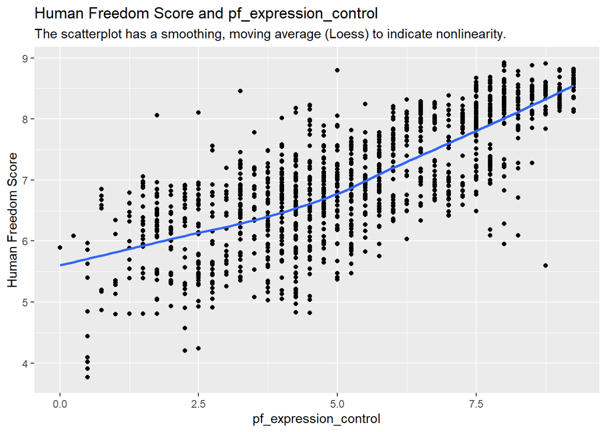

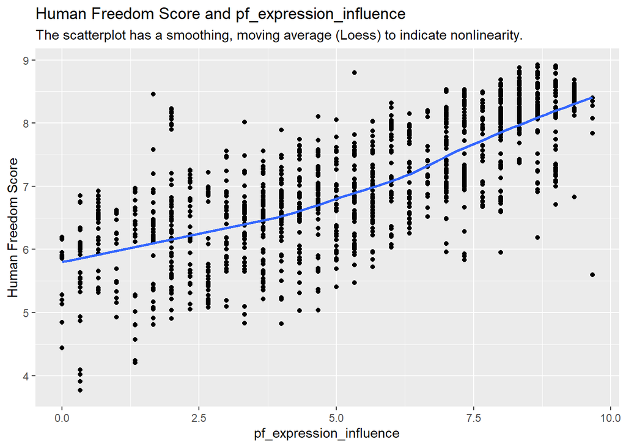

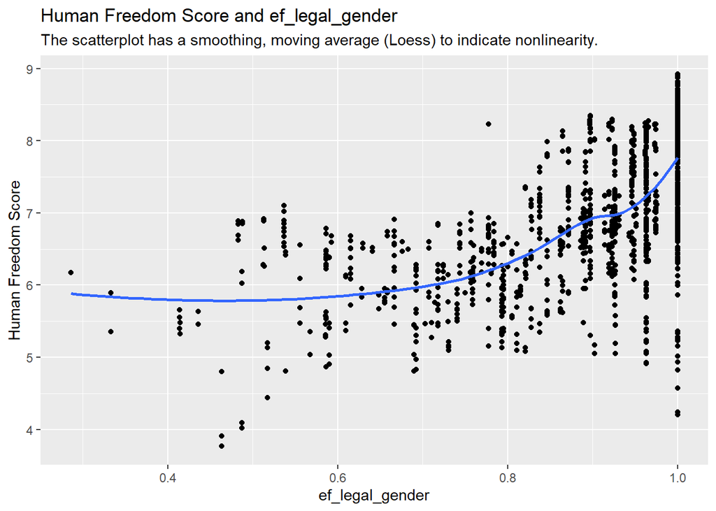

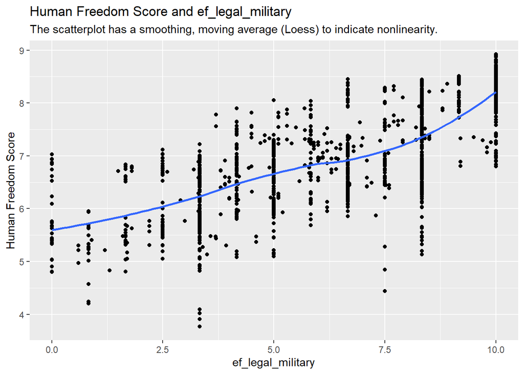

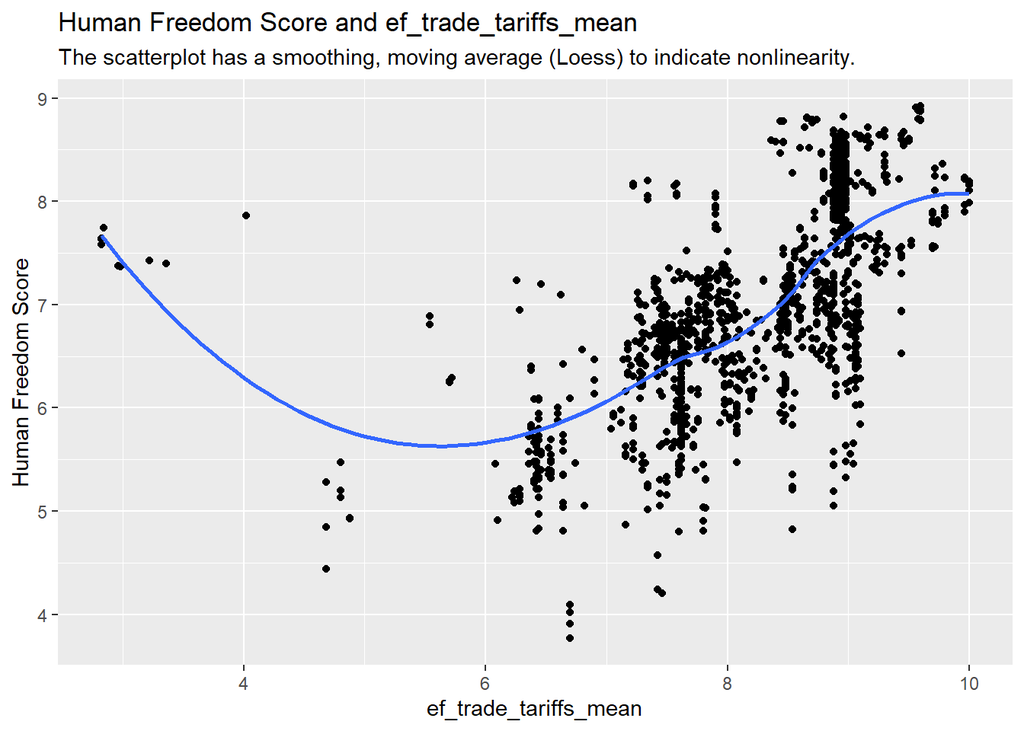

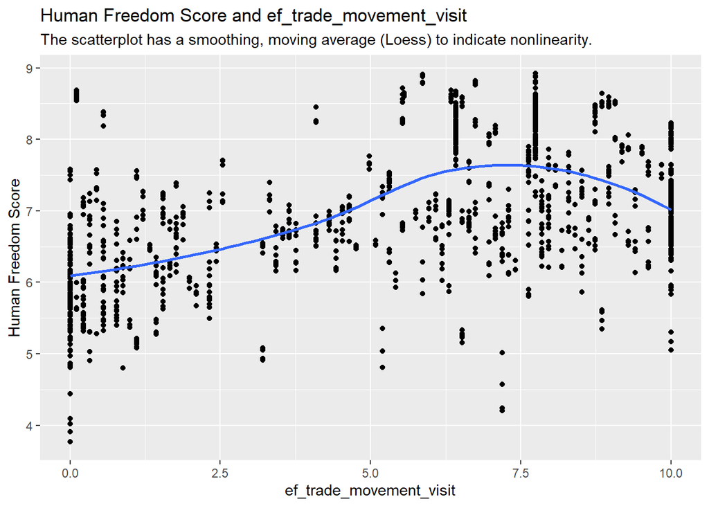

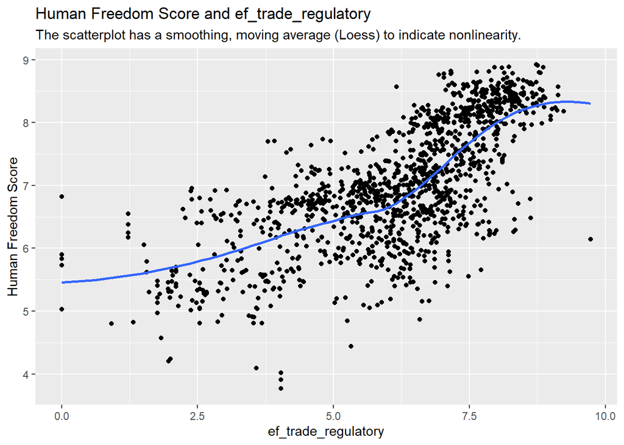

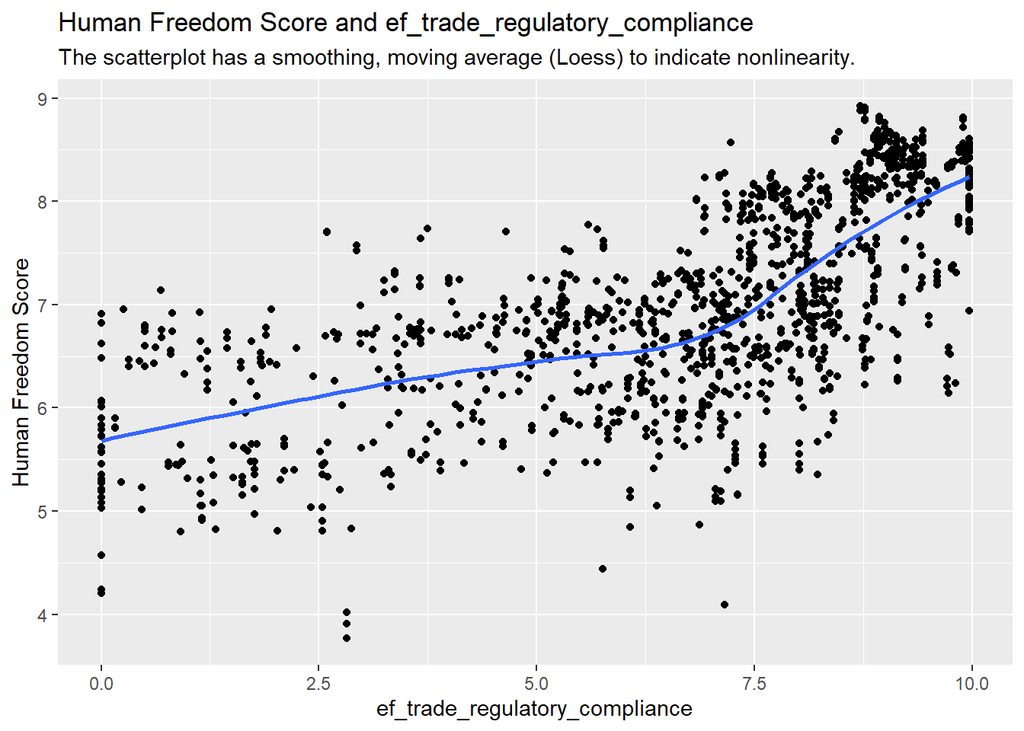

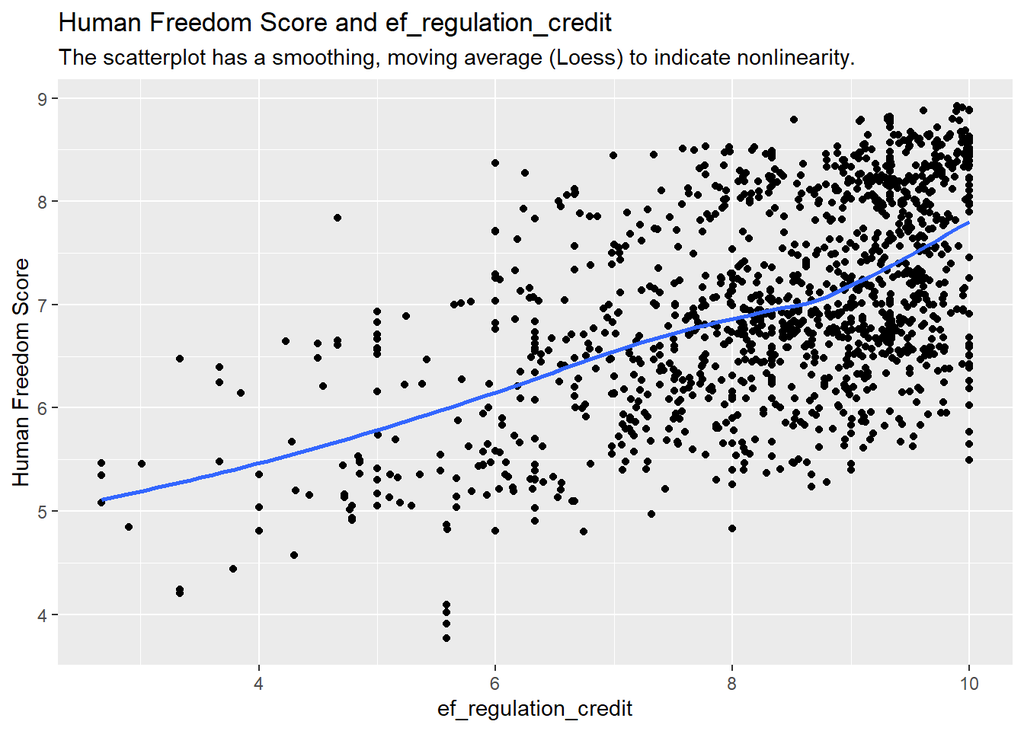

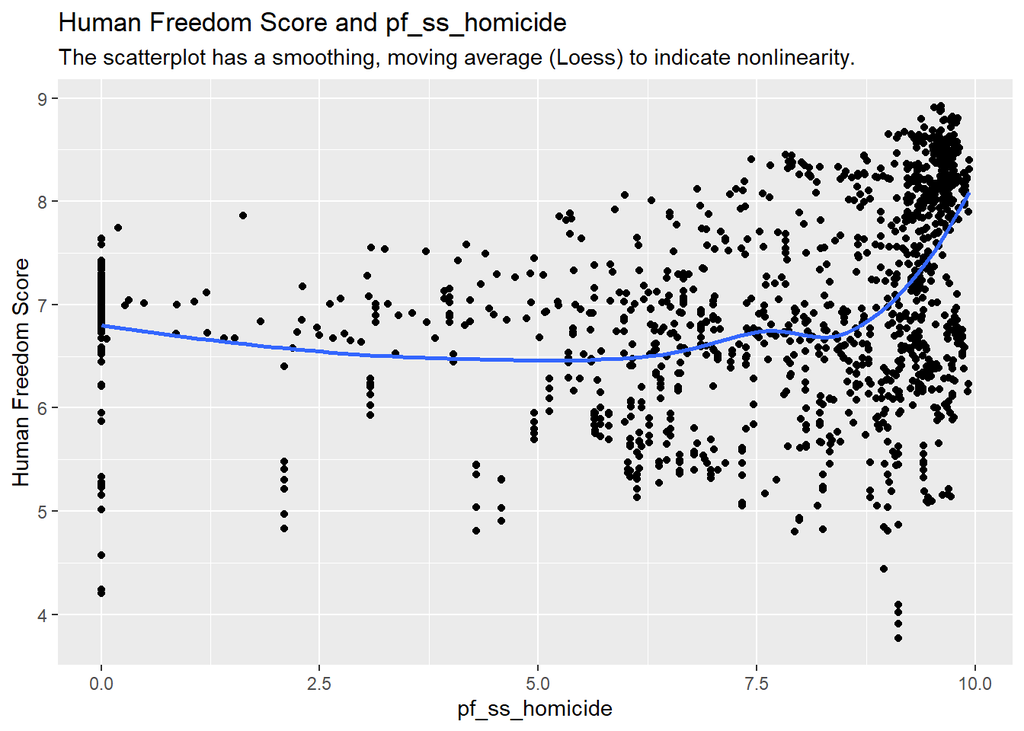

```r
par(mfrow=c(1,1))

for ( i in 1:length(names_of_preds)){
  plot = ggplot(data = hfi_data_combined,
                aes(x = hfi_data_combined[[names_of_preds[i]]], y = hf_score)) +
    geom_point() + geom_smooth(method = loess, formula = y ~ x, se=FALSE) +
    xlab(names_of_preds[i]) + ylab("Human Freedom Score") +
    ggtitle(paste(title = "Human Freedom Score and", names_of_preds[i]),
            subtitle = "The scatterplot has a smoothing, moving average (Loess) to indicate nonlinearity.")

  print(plot)
}
```

These various scatterplots highlight that nearly all predictors have a somewhat linear relationship (even the predictors found in boosting and random forest, like ef_trade_regulatory, ef_trade_regulatory_compliance, ef_regulation_credit). The predictors we will try to see if polynomial regression can improve our simplified MLR model are:

- ef_trade_regulatory
- ef_trade_tariffs_mean
- ef_regulation_credit
- ef_legal_gender
- pf_ss_homicide

```r
# Commentted out for sake of speed. This part takes a long time ~5+ mins. The results are not very interesting.

# set.seed(111)
#
# poly_vars = c("ef_trade_regulatory", "ef_trade_tariffs_mean", "ef_regulation_credit", "ef_legal_gender", "pf_ss_homicide")
# max_poly_term = 5
# coef_matrix = matrix(data = rep(c(0, 0, 0, 0, 0), 5^5), ncol = 5)
# final_poly_cv_mse = rep(100, 5^5)
# i = 1
# for( a in 1:max_poly_term){
#   for( b in 1:max_poly_term){
#     for( c in 1:max_poly_term){
#       for( d in 1:max_poly_term){
#         for( e in 1:max_poly_term){
#           fit = glm(as.formula(paste("hf_score ~", paste(names_of_preds, collapse = " + "),
#                           "+ poly(ef_trade_regulatory,", a, ") + poly(ef_trade_tariffs_mean,",
#                           b, ") + poly(ef_regulation_credit,", c, ") + poly(ef_legal_gender,", d
#                           , ") + poly(pf_ss_homicide,", e, ") -", paste(poly_vars, collapse = " - "))),
#                     data = hfi_data_combined_train)
#           coef_matrix[i, ] = c(a, b, c, d, e)
#           final_poly_cv_mse[i] = cv.glm(hfi_data_combined_train, fit, K = 5)$delta[1]
#           i = i+1
#         }
#       }
#     }
#   }
# }
#
# paste("Minimum Coefs:")
# paste(coef_matrix[which.min(final_poly_cv_mse), ])
# paste("Minimum CV MSE:", round(min(final_poly_cv_mse), 6))
# paste("Minimum CV MSE of Default MLR:", round(final_poly_cv_mse[1], 6))
# paste("Mean TSS of Train Set:", round(mean_tss_train, 6))
```

After running, the above regression, the benefits from the polynomial terms were minimal. The best cross-validated MSE we returned was 0.106 compared to the default model’s 0.11164 cross-validated MSE with **no** polynomial terms. Therefore, we will not add any terms to the MLR model. The improvement is too insignificant, especially as the additional terms were 1 quartic (4th power), 1 cubic, 2 quadratic, and 6 linear terms. That means there are 7 additional degrees of freedom for the model. This model adds complexity, yet fails to deliver more than a 2% increase in R-Squared value.

## 6.6 Random Forest Model, Simplified

```r
# RANDOM FOREST AND BAGGING
set.seed(111)
default_ntrees = 500
simple_random_forests = data.frame(MTry =  seq(from = 1, to = 10, by = 1), Test_MSE = rep(100, 10))

forest_i = 1
for (current_mtry in simple_random_forests$MTry) {
  rf_simplified = randomForest(as.formula(paste("hf_score ~", paste(names_of_preds, collapse = " + "))),
                               data = hfi_data_combined_train,
                               ntree = default_ntrees, mtry = current_mtry)

  yhat = predict(rf_simplified, newdata = hfi_data_combined_test)

  simple_random_forests$MTry[forest_i] = current_mtry
  simple_random_forests$Test_MSE[forest_i] = mean((yhat - hfi_data_combined_test$hf_score)^2)
  forest_i = forest_i + 1
}

paste("The Mean TSS for the Test Set:", round(mean_tss_test, 6))
```

```
## [1] "The Mean TSS for the Test Set: 0.882886"
```

```r
paste("The Test MSE for the Final Simplified MLR Model:", round(final_lm_model_mse, 6))
```

```
## [1] "The Test MSE for the Final Simplified MLR Model: 0.134352"
```

```r
simple_random_forests %>% arrange(Test_MSE)
```

| MTry | Test_MSE |
| --- | --- |
| 4 | 0.04770324 |
| 3 | 0.04821449 |
| 5 | 0.04854603 |
| 2 | 0.04899809 |
| 6 | 0.04935124 |
| 8 | 0.05047776 |
| 7 | 0.05068233 |
| 9 | 0.05081980 |
| 1 | 0.05115384 |
| 10 | 0.05278814 |

```r
temp = simple_random_forests %>% arrange(Test_MSE)
best_mtry_10pred = temp$MTry[1]
best_mse_10pred = round(temp$Test_MSE[1], 5)
```

The 10-predictor subset random forest model is accurate. The Test MSE is consistently around 0.05 for all MTry (Number of variables to consider at each split in tree generation). The best model is MTry = 4 with a Test MSE of 0.0477. This result is significantly improved over the final MLR model Test MSE of 0.134352.

```r
# RANDOM FOREST AND BAGGING
set.seed(111)

simple_random_forests = data.frame(MTry =  seq(from = 1, to = 8, by = 1), Test_MSE = rep(100, 8))
forest_i = 1

for (current_mtry in simple_random_forests$MTry) {
  rf_simplified = randomForest(as.formula(paste("hf_score ~",
                                                paste(names_of_preds, collapse = " + "),
                                                "- ef_trade_regulatory_compliance - pf_expression_influence" )),
                               data = hfi_data_combined_train,
                               ntree = default_ntrees, mtry = current_mtry)

  yhat = predict(rf_simplified, newdata = hfi_data_combined_test)
  simple_random_forests$Test_MSE[forest_i] = mean((yhat - hfi_data_combined_test$hf_score)^2)
  forest_i = forest_i + 1
}

paste("The Mean TSS for the Test Set:", round(mean_tss_test, 6))
```

```
## [1] "The Mean TSS for the Test Set: 0.882886"
```

```r
paste("The Test MSE for the Final Simplified MLR Model:", round(final_lm_model_mse, 6))
```

```
## [1] "The Test MSE for the Final Simplified MLR Model: 0.134352"
```

```r
simple_random_forests %>% arrange(Test_MSE)
```

| MTry | Test_MSE |
| --- | --- |
| 2 | 0.04647152 |
| 3 | 0.04663756 |
| 4 | 0.04735718 |
| 5 | 0.04900835 |
| 1 | 0.04970858 |
| 6 | 0.05053962 |
| 7 | 0.05275419 |
| 8 | 0.05340238 |

```r
temp = simple_random_forests %>% arrange(Test_MSE)
best_mtry_8pred = temp$MTry[1]
best_mse_8pred = round(temp$Test_MSE[1], 5)
```

The 8-predictor subset random forest model is equally as accurate. The lowest Test MSE is 0.04647 with MTry set at 2. These random forest models are very accurate and the 8-predictor subset results in a model that has an R-Squared of roughly 94%. Random forest models seem to capture most of the variance within the HFI with minimal worries about overfit. Most likely this accuracy indicates the HFI’s variance **does** have underlying connections as a model with increasing degrees of freedom can continually deliver high accuracy models without much overfit. As stated before, these simpler models are useful to estimate while having more insight into what affects overall human freedom.

The final model we are using is the 8-predictor subset with MTRY of 2. The results of the model and importance analysis of predictors:

```r
default_ntrees = 500
rf_final = randomForest(as.formula(paste("hf_score ~",
                                              paste(names_of_preds, collapse = " + "),
                                              "- ef_trade_regulatory_compliance - pf_expression_influence" )),
                        data = hfi_data_combined_train, ntree = default_ntrees,
                        mtry = best_mtry_8pred, importance = T)

yhat = predict(rf_final, newdata = hfi_data_combined_test)
rf_final_mse = round(mean((yhat - hfi_data_combined_test$hf_score)^2), 6)
rf_final$importance
```

```
##                            %IncMSE IncNodePurity
## pf_expression_control   0.24791986     218.44974
## ef_legal_gender         0.21253098     136.34933
## ef_legal_military       0.17727805     146.84084
## ef_trade_tariffs_mean   0.20443612     169.85846
## ef_trade_movement_visit 0.12115843      82.87914
## ef_trade_regulatory     0.18540051     168.35430
## ef_regulation_credit    0.07256042      55.98973
## pf_ss_homicide          0.09342418      55.92985
```

```r
rf_final_mse
```

```
## [1] 0.04494
```

```r
print( paste("The Test MSE for 8-Predictor Subset Random Forest: ", round(rf_final_mse, 4), sep = "" ))
```

```
## [1] "The Test MSE for 8-Predictor Subset Random Forest: 0.0449"
```

```r
print( paste("The Estimated R-Squared for 8-Predictor Subset Random Forest: ",
             round((1 - (rf_final_mse / mean_tss_test)) * 100, 2), "%", sep = "" ))
```

```
## [1] "The Estimated R-Squared for 8-Predictor Subset Random Forest: 94.91%"
```

```r
print( paste("The Test MSE for 8-Predictor MLR Model: ", round(final_lm_model_mse, 4), sep = "" ))
```

```
## [1] "The Test MSE for 8-Predictor MLR Model: 0.1344"
```

```r
print( paste("The Estimated R-Squared for 8-Predictor MLR Model: ",
             round((1 - (final_lm_model_mse / mean_tss_test)) * 100, 2), "%", sep = "" ))
```

```
## [1] "The Estimated R-Squared for 8-Predictor MLR Model: 84.78%"
```

Overall, the random forests had exceptional predictive accuracy with the subset of predictors. The R-Squared is roughly 95%. That is an improvement compared to the simplified MLR (R-Squared = 85%). The importance of the random forest indicates nearly all predictors have a degree of relevance (especially compared to the random forest with all 39 predictors).

We strongly believe the 8-predictor subset random forest model is better than the complete 39-predictor model. The 8-predictor model simplifies the complexity of explaining the components of human freedom by removing over 75% of the predictors. The resulting model is nearly as accurate and is easier to see the predictors that are strongly connected to human freedom. The importance highlights that each of the 8 predictors are critical to lowering the MSE.

Additionally, the final random forest model (8-predictor subset) is superior to the final MLR model created earlier. The final MLR model captures roughly 85% of the variance of human freedom compared to the random forest model’s 95%. However, the MLR is more useful for determining the influence each predictor has on the estimated human freedom; so both models are useful.

## 6.7 Boosting Model, Simplified

```r
# BOOSTING
set.seed(111)
par(mfrow=c(1,1))

lambda = 0.01  # the recommended value. we could test more thoroughly, but the amount of time would be large.
default_ntrees = 3000
max_inter_depth = 10  # this is more reasonable, typically, one does not need many leaf nodes per tree

boosting_simplified_test_mse = rep(NA, max_inter_depth)

for( inter_depth in 1:max_inter_depth){
  boosting_gbm = gbm(as.formula(paste("hf_score ~", paste(names_of_preds, collapse = " + " ))),
                     data = hfi_data_combined_train, distribution="gaussian",
                     interaction.depth = inter_depth, n.trees=default_ntrees,
                     shrinkage = lambda, cv.folds = 10)

  yhat = predict(boosting_gbm, newdata = hfi_data_combined_test, n.trees = default_ntrees)
  boosting_simplified_test_mse[inter_depth] = mean((yhat - hfi_data_combined_test$hf_score)^2)

  print(paste("At Maximum Inter-Depth: ", inter_depth))
  print(paste("10-Fold Cross-Validation Error Estimate is",
              round(boosting_gbm$cv.error[default_ntrees], 6)))
  print(paste("Test MSE:", round(boosting_simplified_test_mse[inter_depth], 6)))
  print(paste("Mean TSS of Test Set:", round(mean_tss_test, 6)))
}
```

```
## [1] "At Maximum Inter-Depth:  1"
## [1] "10-Fold Cross-Validation Error Estimate is 0.093557"
## [1] "Test MSE: 0.10245"
## [1] "Mean TSS of Test Set: 0.882886"
## [1] "At Maximum Inter-Depth:  2"
## [1] "10-Fold Cross-Validation Error Estimate is 0.067987"
## [1] "Test MSE: 0.070459"
## [1] "Mean TSS of Test Set: 0.882886"
## [1] "At Maximum Inter-Depth:  3"
## [1] "10-Fold Cross-Validation Error Estimate is 0.056298"
## [1] "Test MSE: 0.057646"
## [1] "Mean TSS of Test Set: 0.882886"
## [1] "At Maximum Inter-Depth:  4"
## [1] "10-Fold Cross-Validation Error Estimate is 0.049961"
## [1] "Test MSE: 0.055207"
```

[output cut: 25 more lines]

```r
best_boosting_inter_depth = 8  # chosen manually looking at results.
final_boosting_test_mse = boosting_simplified_test_mse[8]
```

This boosting model is very accurate with the smaller 10-predictor subset. With more complex individual trees (dictated by the inter_depth hyper-parameter), indicate the model does not suffer much risk of overfit. MEaning, the variance within human freedom can be captured by these 10-predictors quite well. The smallest Test MSE is 0.047 which is comparable to the final 8-predictor subset random forest model above.

We will run the boosting models with an 8-predictor subset removing the potentially confounding predictors ef_trade_regulatory_compliance and pf_expression_influence.

```r
# BOOSTING
set.seed(111)

lambda = 0.01  # the recommended value. we could test more thoroughly, but the amount of time would be large.
default_ntrees = 3000
max_inter_depth = 8  # this is more reasonable, typically, one does not need many leaf nodes per tree

boosting_simplified_test_mse = rep(NA, max_inter_depth)

for( inter_depth in 1:max_inter_depth){
  boosting_gbm = gbm(as.formula(paste("hf_score ~", paste(names_of_preds, collapse = " + " ),
                                      "- ef_trade_regulatory_compliance - pf_expression_influence" )),
                     data = hfi_data_combined_train, distribution="gaussian",
                     interaction.depth = inter_depth, n.trees=default_ntrees,
                     shrinkage = lambda, cv.folds = 10)

  yhat = predict(boosting_gbm, newdata = hfi_data_combined_test, n.trees = default_ntrees)
  boosting_simplified_test_mse[inter_depth] = mean((yhat - hfi_data_combined_test$hf_score)^2)

  print(paste("At Maximum Inter-Depth: ", inter_depth))
  print(paste("10-Fold Cross-Validation Error Estimate is",
              round(boosting_gbm$cv.error[default_ntrees], 6)))
  print(paste("Test MSE:", round(boosting_simplified_test_mse[inter_depth], 6)))
  print(paste("Mean TSS of Test Set:", round(mean_tss_test, 6)))
}
```

```
## [1] "At Maximum Inter-Depth:  1"
## [1] "10-Fold Cross-Validation Error Estimate is 0.098747"
## [1] "Test MSE: 0.10434"
## [1] "Mean TSS of Test Set: 0.882886"
## [1] "At Maximum Inter-Depth:  2"
## [1] "10-Fold Cross-Validation Error Estimate is 0.070641"
## [1] "Test MSE: 0.073336"
## [1] "Mean TSS of Test Set: 0.882886"
## [1] "At Maximum Inter-Depth:  3"
## [1] "10-Fold Cross-Validation Error Estimate is 0.058842"
## [1] "Test MSE: 0.061472"
## [1] "Mean TSS of Test Set: 0.882886"
## [1] "At Maximum Inter-Depth:  4"
## [1] "10-Fold Cross-Validation Error Estimate is 0.052378"
## [1] "Test MSE: 0.059604"
```

[output cut: 17 more lines]

Here is our final 8-predictor subset boosting model with inter-depth 6 (after 6, the model does not seem to benefit much from the additional model variance).

```r
default_ntrees = 3000
lambda = 0.01

final_boosting_gbm = gbm(as.formula(paste("hf_score ~", paste(names_of_preds, collapse = " + " ),
                                      "- ef_trade_regulatory_compliance - pf_expression_influence" )),
                         data = hfi_data_combined_train, distribution="gaussian",
                         interaction.depth = 6, n.trees=default_ntrees,
                         shrinkage = lambda, cv.folds = 10)

summary(final_boosting_gbm, plot=F)
```

|  | var | rel.inf |
| --- | --- | --- |
| pf_expression_control | pf_expression_control | 31.560413 |
| ef_trade_regulatory | ef_trade_regulatory | 16.709604 |
| ef_trade_tariffs_mean | ef_trade_tariffs_mean | 16.658093 |
| ef_legal_gender | ef_legal_gender | 10.862381 |
| ef_legal_military | ef_legal_military | 6.742109 |
| ef_regulation_credit | ef_regulation_credit | 6.184339 |
| ef_trade_movement_visit | ef_trade_movement_visit | 6.122543 |
| pf_ss_homicide | pf_ss_homicide | 5.160518 |

```r
yhat = predict(boosting_gbm, newdata = hfi_data_combined_test, n.trees = default_ntrees)
final_boosting_test_mse = mean((yhat - hfi_data_combined_test$hf_score)^2)
final_boosting_test_r2 = round((1 - (final_boosting_test_mse / mean_tss_test)) * 100, 2)

print( paste("The Test MSE for 8-Predictor Subset Boosting Model: ", round(final_boosting_test_mse, 4), sep = "" ))
```

```
## [1] "The Test MSE for 8-Predictor Subset Boosting Model: 0.0523"
```

```r
print( paste("The Estimated R-Squared for 8-Predictor Subset Boosting Model: ",
             round((1 - (final_boosting_test_mse / mean_tss_test)) * 100, 2), "%", sep = "" ))
```

```
## [1] "The Estimated R-Squared for 8-Predictor Subset Boosting Model: 94.07%"
```

```r
print( paste("The Test MSE for 8-Predictor Subset Random Forest: ", round(rf_final_mse, 4), sep = "" ))
```

```
## [1] "The Test MSE for 8-Predictor Subset Random Forest: 0.0449"
```

```r
print( paste("The Estimated R-Squared for 8-Predictor Subset Random Forest: ",
             round((1 - (rf_final_mse / mean_tss_test)) * 100, 2), "%", sep = "" ))
```

```
## [1] "The Estimated R-Squared for 8-Predictor Subset Random Forest: 94.91%"
```

```r
print( paste("The Test MSE for 8-Predictor MLR Model: ", round(final_lm_model_mse, 4), sep = "" ))
```

```
## [1] "The Test MSE for 8-Predictor MLR Model: 0.1344"
```

```r
print( paste("The Estimated R-Squared for 8-Predictor MLR Model: ",
             round((1 - (final_lm_model_mse / mean_tss_test)) * 100, 2), "%", sep = "" ))
```

```
## [1] "The Estimated R-Squared for 8-Predictor MLR Model: 84.78%"
```

Our final boosting model is comparable to the final random forest model (also 8-predictor subset); while both tree-based models outperform the final MLR model considerably (R-Squared is different by roughly 10%; 85% vs 95% where 100% is perfect). However, the boosting model is not better than the random forest model as it is more complex and has a slightly worse error. We prefer the random forest model for use with predictions and MLR for inferencing on the predictors to gage the effect predictors have on human freedom.

## 6.8 Comparision of Model Predictive Accuracy, Complexity, and Predictor Inferencing

```r
final_results_matrix = matrix(
  data=c(round(final_lm_model_mse, 4), round(rf_final_mse, 4),
         round(final_boosting_test_mse, 4),
         round((1 - final_lm_model_mse / mean_tss_test) * 100, 2),
         round((1 - rf_final_mse / mean_tss_test) * 100, 2),
         round((1 - final_boosting_test_mse / mean_tss_test) * 100, 2)), nrow=3, ncol=2)
colnames(final_results_matrix) = c("Test MSE", "Estimate R-Squared (%)")
rownames(final_results_matrix) = c("Multiple Linear Regression with 8 Predictors",
                                   "Random Forest with 8 Predictors and Mtry of 2",
                                   "Boosting with 8 Predictors and Inter-Depth of 6")

print(as.data.frame(final_results_matrix))
```

```
##                                                 Test MSE Estimate R-Squared (%)
## Multiple Linear Regression with 8 Predictors      0.1344                  84.78
## Random Forest with 8 Predictors and Mtry of 2     0.0449                  94.91
## Boosting with 8 Predictors and Inter-Depth of 6   0.0523                  94.07
```

These final results show that biasing the dataset significantly (using only 20-25% of the total predictors available) still yields powerful, accurate models. The MLR model is clearly inferior to the ensemble methods in accuracy. However, the MLR does allow for inferencing, which shows all 8 predictors are significantly influencing the estimate for human freedom.

The random forest and boosting models both are the models for accuracy. We actually prefer these boosting and random forest models compared to the 39-predictor versions as the subset of predictors removes data needed to estimate. However, it is important to note that fewer predictors does not mean simpler, per-se. The random forest and boosting models are complex still as they build many trees (500 and 3000, respectively, for these specific models though could be more tailored to potentially improve accuracy), which drives the non-linearity of the models and the high amount of variance captured by these models. Yet, the amount of data needed to run these random forest and boosting models is less stringent (fewer predictors == fewer observations needed).

The more complex the boosting and random forest model became, the better the accuracy (especially boosting and inter-depth hyper-parameter). This finding shows that the variance within human freedom can be captured with the predictors with little risk of overfitting. Normally, these more complex and flexible models can capture increasingly non-linear and subtle trends, but with this increased sensitivity to patterns, the models often find patterns where they do not exist. But, the HFI does not seem to have this issue. The patterns found by the flexible boosting model are actually patterns within the entire dataset. Most likely because the dataset is an aggregate of the variables, so human freedom is directly (or largely) calculated by the predictors we are utilizing to estimate human freedom.

#### In short: The MLR model for analyzing predictor’s affects on human freedom and random forest model for accurately estimating what humna freedom is with the 8-predictor subset.

### The 8-predictor subset is:

pf_expression_control, ef_legal_gender, ef_legal_military, ef_trade_tariffs_mean, ef_trade_movement_visit, ef_trade_regulatory, ef_regulation_credit, pf_ss_homicide,

# 7. Our Final Thoughts on Complete Analysis

Overall, the dataset has variables that are all correlated and inter-connected. The strong relationships between the variables result in very accurate models, even the simple ones like MLR that tend to have weaker predictive ability. Hence, there is not much to takeaway from the prediction side of the various models, but to focus on what predictors are the strongest markers for greater human freedom (or lesser).

We find that MLR, random forest, and boosting models all tend to indicate that these predictors tend to be important / significant / relevant. We list some of them out under section 6.3. Here is the list again:

1. pf_expression_control (found in MLR, random forest, boosting)
2. pf_expression_influence (found in MLR, random forest, boosting)
3. ef_legal_gender (found in MLR, random forest, boosting)
4. ef_legal_military (found in MLR, random forest, boosting)
5. ef_trade_tariffs_mean (found in MLR, random forest, boosting)
6. ef_trade_movement_visit (found in MLR, random forest, boosting)
7. ef_trade_regulatory (found in random forest and boosting)
8. ef_trade_regulatory_compliance (found in random forest and boosting)
9. ef_regulation_credit (found in random forest and boosting)
10. pf_ss_homicide (found in MLR and random forest)

### Some notes of confounders within the MLR:

We found 2 pairs of confounding predictors Confounding predictors indicate that the predictors are capturing the same variance and are correlated themselves.

1. pf_expression_control and pf_expression_influence
2. ef_trade_regulatory_compliance and ef_trade_regulatory

## Which Model is Best:

We recommend using the MLR if all 31 predictors required for the MLR model given by best-subset or forward selection are present with valid observations. Otherwise, the simpler, 8-predictor random forest or boosting models are preferable. IF computation time is a concern, random forest is better as it can be generated quicker than the boosting. Boosting is slightly less accurate and is more resource intensive to generate the model.

## Final Conclusions and Takeaways

Overall, this dataset clearly has inter-connected variables. Most likely the human freedom score is an aggregate of the other 39+ predictors (the additional predictors we ignored due to numerous N/As). Thus, nearly all methods should deliver good results as the dataset is formulaically related among the variables. Regardless, the ensemble methods’ accuracy (random forest and boosting) was impressive. These models can often predict human values very well (like rating human freedom metrics). With such high accuracy of the random forest and boosting models, we believe there is a possibility that the dataset variables are not completely objectively selected.

In the beginning of the CATO institute manual for the Human Freedom Index, they bash and attack the lack of freedom within China. This biased stance from the intro of a paper, combined with calculating human freedom as a measure based on **western ideals** of freedom and **libertarian ideals** distorts human freedom. They are not comparing their human freedom metric to surveys of individuals’ own perception of freedom within their home country. Obviously, the survey in Russia or China would have a high likelihood of people lying to ensure they are not hurt, which helps to further CATO’s own opinions on human freedom. On the other hand, they may find citizens in Norway feel more liberated and free than Americans, despite their measurement.

OVerall, the Human Freedom Index is an attempt to measure and quantify human freedom by the CATO Institute. Our findings and models indicate that the index is overly complex and could be simplified by focusing on 10 main indicators for human freedom (listed above under section 7 Conclusion). The dataset is also using the western and libertarian views on freedom; often focusing on individual freedom versus collective well-being like some of the eastern world focuses on (like South Korea, Japan).